# RNA-seq analysis in R

Differential expression analysis

**Authors: Belinda Phipson, Anna Trigos, Matt Ritchie, Maria Doyle, Harriet Dashnow, Charity Law**

## Resources and data files

This material has been created using the following resources:  
http://www.statsci.org/smyth/pubs/QLedgeRPreprint.pdf (Lun, Chen, and Smyth 2016)  
http://monashbioinformaticsplatform.github.io/RNAseq-DE-analysis-with-R/99-RNAseq_DE_analysis_with_R.html

Data files downloaded from:  
ftp://ftp.ncbi.nlm.nih.gov/geo/series/GSE60nnn/GSE60450/suppl/GSE60450_Lactation-GenewiseCounts.txt.gz http://bioinf.wehi.edu.au/software/MSigDB/mouse_c2_v5.rdata http://bioinf.wehi.edu.au/software/MSigDB/mouse_H_v5.rdata

Data files are available from: https://figshare.com/s/1d788fd384d33e913a2a You should download these files and place them in your `/data` directory.

Data files:  
sampleinfo.txt SampleInfo_Corrected.txt GSE60450_Lactation-GenewiseCounts.txt  
mouse_c2_v5.rdata  
mouse_H_v5.rdata ResultsTable_small.txt small_counts.txt

Packages used: limma, edgeR, gplots, org.Mm.eg.db, RColorBrewer, Glimma

## Overview

- Reading in table of counts
- Filtering lowly expressed genes
- Quality control
- Normalisation for composition bias
- Differential expression analysis
- Testing relative to a threshold
- Visualisation
- Gene set testing

## Introduction and data import

Measuring gene expression on a genome-wide scale has become common practice over the last two decades or so, with microarrays predominantly used pre-2008. With the advent of next generation sequencing technology in 2008, an increasing number of scientists use this technology to measure and understand changes in gene expression in often complex systems. As sequencing costs have decreased, using RNA-Seq to simultaneously measure the expression of tens of thousands of genes for multiple samples has never been easier. The cost of these experiments has now moved from generating the data to storing and analysing it.

There are many steps involved in analysing an RNA-Seq experiment. Analysing an RNAseq experiment begins with sequencing reads. These are aligned to a reference genome, then the number of reads mapped to each gene can be counted. This results in a table of counts, which is what we perform statistical analyses on in R. While mapping and counting are important and necessary tasks, today we will be starting from the count data and getting stuck into analysis.

First, let’s load all the packages we will need to analyse the data.

```r
library(edgeR)
          library(limma)
          library(Glimma)
          library(gplots)
          library(org.Mm.eg.db)
          library(RColorBrewer)
```

### Mouse mammary gland dataset

The data for this tutorial comes from a Nature Cell Biology paper, [*EGF-mediated induction of Mcl-1 at the switch to lactation is essential for alveolar cell survival*](http://www.ncbi.nlm.nih.gov/pubmed/25730472) (Fu et al. 2015). Both the raw data (sequence reads) and processed data (counts) can be downloaded from Gene Expression Omnibus database (GEO) under accession number GSE60450.

This study examines the expression profiles of basal stem-cell enriched cells (B) and committed luminal cells (L) in the mammary gland of virgin, pregnant and lactating mice. Six groups are present, with one for each combination of cell type and mouse status. Each group contains two biological replicates. We will first use the counts file as a starting point for our analysis. This data has already been aligned to the mouse genome. The command line tool featureCounts (Liao, Smyth, and Shi 2014) was used to count reads mapped to mouse genes from Refseq annotation (see the [paper](http://www.ncbi.nlm.nih.gov/pubmed/25730472) for details).

### Reading in the data

*Set up an RStudio project specifying the directory where you have saved the `/data` directory*. Download and read in the data.

```r
# Read the data into R
          seqdata <- read.delim("data/GSE60450_Lactation-GenewiseCounts.txt", stringsAsFactors = FALSE)
          # Read the sample information into R
          sampleinfo <- read.delim("data/SampleInfo.txt")
```

Let’s take a look at the data. You can use the `head` command to see the first 6 lines. The `dim` command will tell you how many rows and columns the data frame has.

```r
head(seqdata)
```

```
  EntrezGeneID Length MCL1.DG_BC2CTUACXX_ACTTGA_L002_R1
          1       497097   3634                               438
          2    100503874   3259                                 1
          3    100038431   1634                                 0
          4        19888   9747                                 1
          5        20671   3130                               106
          6        27395   4203                               309
            MCL1.DH_BC2CTUACXX_CAGATC_L002_R1 MCL1.DI_BC2CTUACXX_ACAGTG_L002_R1
          1                               300                                65
          2                                 0                                 1
          3                                 0                                 0
          4                                 1                                 0
          5                               182                                82
          6                               234                               337
            MCL1.DJ_BC2CTUACXX_CGATGT_L002_R1 MCL1.DK_BC2CTUACXX_TTAGGC_L002_R1
```

[output cut: 34 more lines]

```r
dim(seqdata)
```

```
[1] 27179    14
```

The `seqdata` object contains information about genes (one gene per row), the first column has the Entrez gene id, the second has the gene length and the remaining columns contain information about the number of reads aligning to the gene in each experimental sample. There are two replicates for each cell type and timepoint (detailed sample info can be found in file “GSE60450_series_matrix.txt” from the [GEO website](http://www.ncbi.nlm.nih.gov/geo/query/acc.cgi?acc=GSE60450)). The sampleinfo file contains basic information about the samples that we will need for the analysis today.

```r
sampleinfo
```

```
                            FileName SampleName CellType   Status
          1  MCL1.DG_BC2CTUACXX_ACTTGA_L002_R1    MCL1.DG  luminal   virgin
          2  MCL1.DH_BC2CTUACXX_CAGATC_L002_R1    MCL1.DH    basal   virgin
          3  MCL1.DI_BC2CTUACXX_ACAGTG_L002_R1    MCL1.DI    basal pregnant
          4  MCL1.DJ_BC2CTUACXX_CGATGT_L002_R1    MCL1.DJ    basal pregnant
          5  MCL1.DK_BC2CTUACXX_TTAGGC_L002_R1    MCL1.DK    basal  lactate
          6  MCL1.DL_BC2CTUACXX_ATCACG_L002_R1    MCL1.DL    basal  lactate
          7  MCL1.LA_BC2CTUACXX_GATCAG_L001_R1    MCL1.LA    basal   virgin
          8  MCL1.LB_BC2CTUACXX_TGACCA_L001_R1    MCL1.LB  luminal   virgin
          9  MCL1.LC_BC2CTUACXX_GCCAAT_L001_R1    MCL1.LC  luminal pregnant
          10 MCL1.LD_BC2CTUACXX_GGCTAC_L001_R1    MCL1.LD  luminal pregnant
          11 MCL1.LE_BC2CTUACXX_TAGCTT_L001_R1    MCL1.LE  luminal  lactate
          12 MCL1.LF_BC2CTUACXX_CTTGTA_L001_R1    MCL1.LF  luminal  lactate
```

We will be manipulating and reformating the counts matrix into a suitable format for downstream analysis. The first two columns in the `seqdata` dataframe contain annotation information. We need to make a new matrix containing only the counts, but we can store the gene identifiers (the `EntrezGeneID` column) as rownames. We will add more annotation information about each gene later on in the workshop.

### Format the data

Let’s create a new data object, `countdata`, that contains only the counts for the 12 samples.

```r
# Remove first two columns from seqdata
          countdata <- seqdata[,-(1:2)]
          # Look at the output
          head(countdata)
```

```
  MCL1.DG_BC2CTUACXX_ACTTGA_L002_R1 MCL1.DH_BC2CTUACXX_CAGATC_L002_R1
          1                               438                               300
          2                                 1                                 0
          3                                 0                                 0
          4                                 1                                 1
          5                               106                               182
          6                               309                               234
            MCL1.DI_BC2CTUACXX_ACAGTG_L002_R1 MCL1.DJ_BC2CTUACXX_CGATGT_L002_R1
          1                                65                               237
          2                                 1                                 1
          3                                 0                                 0
          4                                 0                                 0
          5                                82                               105
          6                               337                               300
            MCL1.DK_BC2CTUACXX_TTAGGC_L002_R1 MCL1.DL_BC2CTUACXX_ATCACG_L002_R1
```

[output cut: 27 more lines]

```r
# Store EntrezGeneID as rownames
          rownames(countdata) <- seqdata[,1]
```

Take a look at the output

```r
head(countdata)
```

```
          MCL1.DG_BC2CTUACXX_ACTTGA_L002_R1
          497097                                  438
          100503874                                 1
          100038431                                 0
          19888                                     1
          20671                                   106
          27395                                   309
                    MCL1.DH_BC2CTUACXX_CAGATC_L002_R1
          497097                                  300
          100503874                                 0
          100038431                                 0
          19888                                     1
          20671                                   182
          27395                                   234
                    MCL1.DI_BC2CTUACXX_ACAGTG_L002_R1
```

[output cut: 69 more lines]

Now take a look at the column names

```r
colnames(countdata)
```

```
 [1] "MCL1.DG_BC2CTUACXX_ACTTGA_L002_R1"
           [2] "MCL1.DH_BC2CTUACXX_CAGATC_L002_R1"
           [3] "MCL1.DI_BC2CTUACXX_ACAGTG_L002_R1"
           [4] "MCL1.DJ_BC2CTUACXX_CGATGT_L002_R1"
           [5] "MCL1.DK_BC2CTUACXX_TTAGGC_L002_R1"
           [6] "MCL1.DL_BC2CTUACXX_ATCACG_L002_R1"
           [7] "MCL1.LA_BC2CTUACXX_GATCAG_L001_R1"
           [8] "MCL1.LB_BC2CTUACXX_TGACCA_L001_R1"
           [9] "MCL1.LC_BC2CTUACXX_GCCAAT_L001_R1"
          [10] "MCL1.LD_BC2CTUACXX_GGCTAC_L001_R1"
          [11] "MCL1.LE_BC2CTUACXX_TAGCTT_L001_R1"
          [12] "MCL1.LF_BC2CTUACXX_CTTGTA_L001_R1"
```

These are the sample names which are pretty long so we’ll shorten these to contain only the relevant information about each sample. We will use the `substr` command to extract the first 7 characters and use these as the colnames.

```r
# using substr, you extract the characters starting at position 1 and stopping at position 7 of the colnames
          colnames(countdata) <- substr(colnames(countdata),start=1,stop=7)
```

Take a look at the output

```r
head(countdata)
```

```
          MCL1.DG MCL1.DH MCL1.DI MCL1.DJ MCL1.DK MCL1.DL MCL1.LA MCL1.LB
          497097        438     300      65     237     354     287       0       0
          100503874       1       0       1       1       0       4       0       0
          100038431       0       0       0       0       0       0       0       0
          19888           1       1       0       0       0       0      10       3
          20671         106     182      82     105      43      82      16      25
          27395         309     234     337     300     290     270     560     464
                    MCL1.LC MCL1.LD MCL1.LE MCL1.LF
          497097          0       0       0       0
          100503874       0       0       0       0
          100038431       0       0       0       0
          19888          10       2       0       0
          20671          18       8       3      10
          27395         489     328     307     342
```

Note that the column names are now the same as `SampleName` in the `sampleinfo` file. This is good because it means our sample information in `sampleinfo` is in the same order as the columns in `countdata`.

```r
table(colnames(countdata)==sampleinfo$SampleName)
```

```
          TRUE
            12
```

## Filtering to remove lowly expressed genes

Genes with very low counts across all libraries provide little evidence for differential expression and they interfere with some of the statistical approximations that are used later in the pipeline. They also add to the multiple testing burden when estimating false discovery rates, reducing power to detect differentially expressed genes. These genes should be filtered out prior to further analysis.

There are a few ways to filter out lowly expressed genes. When there are biological replicates in each group, in this case we have a sample size of 2 in each group, we favour filtering on a minimum counts per million threshold present in at least 2 samples. Two represents the smallest sample size for each group in our experiment. In this dataset, we choose to retain genes if they are expressed at a counts-per-million (CPM) above 0.5 in at least two samples.

We’ll use the `cpm` function from the *edgeR* library (M D Robinson, McCarthy, and Smyth 2010) to generate the CPM values and then filter. Note that by converting to CPMs we are normalising for the different sequencing depths for each sample.

```r
# Obtain CPMs
          myCPM <- cpm(countdata)
          # Have a look at the output
          head(myCPM)
```

```
              MCL1.DG     MCL1.DH     MCL1.DI     MCL1.DJ   MCL1.DK
          497097    18.85684388 13.77543859  2.69700983 10.45648006 16.442685
          100503874  0.04305215  0.00000000  0.04149246  0.04412017  0.000000
          100038431  0.00000000  0.00000000  0.00000000  0.00000000  0.000000
          19888      0.04305215  0.04591813  0.00000000  0.00000000  0.000000
          20671      4.56352843  8.35709941  3.40238163  4.63261775  1.997275
          27395     13.30311589 10.74484210 13.98295863 13.23605071 13.469996
                       MCL1.DL    MCL1.LA    MCL1.LB    MCL1.LC     MCL1.LD
          497097    14.3389690  0.0000000  0.0000000  0.0000000  0.00000000
          100503874  0.1998463  0.0000000  0.0000000  0.0000000  0.00000000
          100038431  0.0000000  0.0000000  0.0000000  0.0000000  0.00000000
          19888      0.0000000  0.4903857  0.1381969  0.4496078  0.09095771
          20671      4.0968483  0.7846171  1.1516411  0.8092940  0.36383085
          27395     13.4896224 27.4615975 21.3744588 21.9858214 14.91706476
                       MCL1.LE    MCL1.LF
          497097     0.0000000  0.0000000
          100503874  0.0000000  0.0000000
          100038431  0.0000000  0.0000000
          19888      0.0000000  0.0000000
          20671      0.1213404  0.4055595
          27395     12.4171715 13.8701357
```

```r
# Which values in myCPM are greater than 0.5?
          thresh <- myCPM > 0.5
          # This produces a logical matrix with TRUEs and FALSEs
          head(thresh)
```

```
          MCL1.DG MCL1.DH MCL1.DI MCL1.DJ MCL1.DK MCL1.DL MCL1.LA MCL1.LB
          497097       TRUE    TRUE    TRUE    TRUE    TRUE    TRUE   FALSE   FALSE
          100503874   FALSE   FALSE   FALSE   FALSE   FALSE   FALSE   FALSE   FALSE
          100038431   FALSE   FALSE   FALSE   FALSE   FALSE   FALSE   FALSE   FALSE
          19888       FALSE   FALSE   FALSE   FALSE   FALSE   FALSE   FALSE   FALSE
          20671        TRUE    TRUE    TRUE    TRUE    TRUE    TRUE    TRUE    TRUE
          27395        TRUE    TRUE    TRUE    TRUE    TRUE    TRUE    TRUE    TRUE
                    MCL1.LC MCL1.LD MCL1.LE MCL1.LF
          497097      FALSE   FALSE   FALSE   FALSE
          100503874   FALSE   FALSE   FALSE   FALSE
          100038431   FALSE   FALSE   FALSE   FALSE
          19888       FALSE   FALSE   FALSE   FALSE
          20671        TRUE   FALSE   FALSE   FALSE
          27395        TRUE    TRUE    TRUE    TRUE
```

```r
# Summary of how many TRUEs there are in each row
          # There are 11433 genes that have TRUEs in all 12 samples.
          table(rowSums(thresh))
```

```
              0     1     2     3     4     5     6     7     8     9    10    11
          10857   518   544   307   346   307   652   323   547   343   579   423
             12
          11433
```

```r
# we would like to keep genes that have at least 2 TRUES in each row of thresh
          keep <- rowSums(thresh) >= 2
          # Subset the rows of countdata to keep the more highly expressed genes
          counts.keep <- countdata[keep,]
          summary(keep)
```

```
   Mode   FALSE    TRUE
          logical   11375   15804
```

```r
dim(counts.keep)
```

```
[1] 15804    12
```

A CPM of 0.5 is used as it corresponds to a count of 10-15 for the library sizes in this data set. If the count is any smaller, it is considered to be very low, indicating that the associated gene is not expressed in that sample. A requirement for expression in two or more libraries is used as each group contains two replicates. This ensures that a gene will be retained if it is only expressed in one group. Smaller CPM thresholds are usually appropriate for larger libraries. As a general rule, a good threshold can be chosen by identifying the CPM that corresponds to a count of 10, which in this case is about 0.5. You should filter with CPMs rather than filtering on the counts directly, as the latter does not account for differences in library sizes between samples.

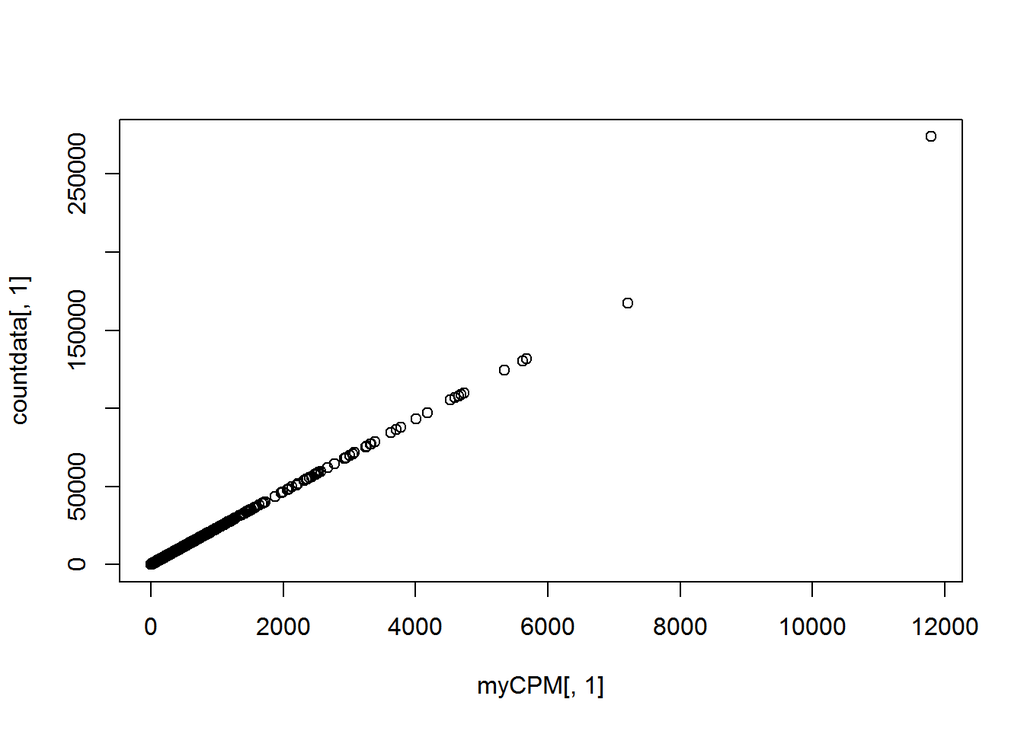

```r
# Let's have a look and see whether our threshold of 0.5 does indeed correspond to a count of about 10-15
          # We will look at the first sample
          plot(myCPM[,1],countdata[,1])
```

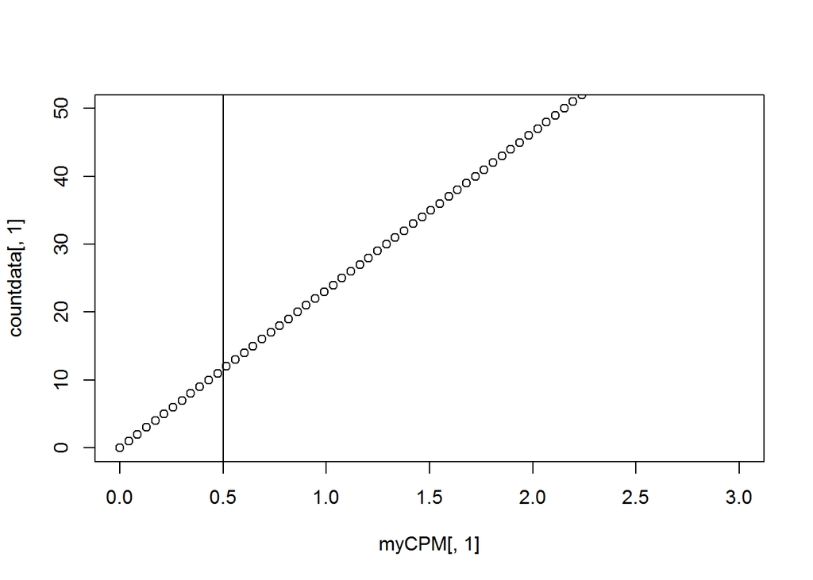

```r
# Let us limit the x and y-axis so we can actually look to see what is happening at the smaller counts
          plot(myCPM[,1],countdata[,1],ylim=c(0,50),xlim=c(0,3))
          # Add a vertical line at 0.5 CPM
          abline(v=0.5)
```

## Challenge

> 1. Plot the counts-per-million versus counts for the second sample.
> 2. Add a vertical line at 0.5 and a horizontal line at 10.
> 3. Add the lines again, colouring them blue

> HINT: use the `col` parameter.

**Solution**

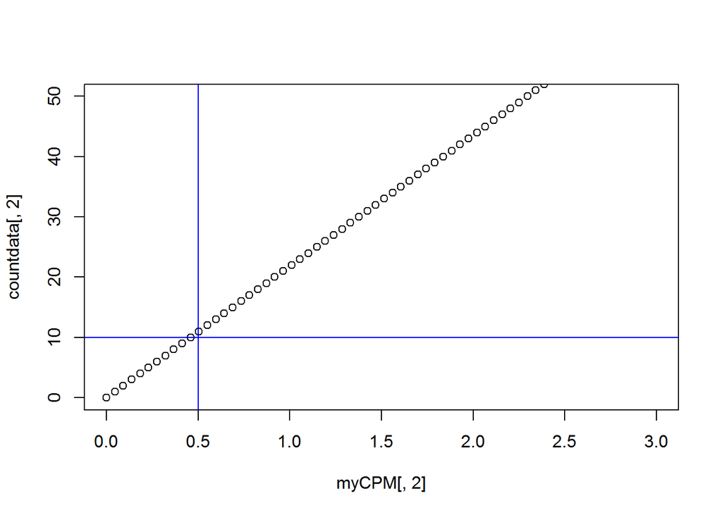

Note: When in doubt, a threshold of 1 CPM in at least *minimum* group sample size is a good rule of thumb.

## Convert counts to DGEList object

Next we’ll create a `DGEList` object. This is an object used by *edgeR* to store count data. It has a number of slots for storing various parameters about the data.

```r
y <- DGEList(counts.keep)
          # have a look at y
          y
```

```
An object of class "DGEList"
          $counts
                 MCL1.DG MCL1.DH MCL1.DI MCL1.DJ MCL1.DK MCL1.DL MCL1.LA MCL1.LB
          497097     438     300      65     237     354     287       0       0
          20671      106     182      82     105      43      82      16      25
          27395      309     234     337     300     290     270     560     464
          18777      652     515     948     935     928     791     826     862
          21399     1604    1495    1721    1317    1159    1066    1334    1258
                 MCL1.LC MCL1.LD MCL1.LE MCL1.LF
          497097       0       0       0       0
          20671       18       8       3      10
          27395      489     328     307     342
          18777      668     646     544     581
          21399     1068     926     508     500
          15799 more rows ...

          $samples
                  group lib.size norm.factors
          MCL1.DG     1 23218026            1
          MCL1.DH     1 21768136            1
          MCL1.DI     1 24091588            1
          MCL1.DJ     1 22656713            1
          MCL1.DK     1 21522033            1
          7 more rows ...
```

```r
# See what slots are stored in y
          names(y)
```

```
[1] "counts"  "samples"
```

```r
# Library size information is stored in the samples slot
          y$samples
```

```
        group lib.size norm.factors
          MCL1.DG     1 23218026            1
          MCL1.DH     1 21768136            1
          MCL1.DI     1 24091588            1
          MCL1.DJ     1 22656713            1
          MCL1.DK     1 21522033            1
          MCL1.DL     1 20008326            1
          MCL1.LA     1 20384562            1
          MCL1.LB     1 21698793            1
          MCL1.LC     1 22235847            1
          MCL1.LD     1 21982745            1
          MCL1.LE     1 24719697            1
          MCL1.LF     1 24652963            1
```

## Quality control

Now that we have got rid of the lowly expressed genes and have our counts stored in a `DGEList` object, we can look at a few different plots to check that the data is good quality, and that the samples are as we would expect.

### Library sizes and distribution plots

First, we can check how many reads we have for each sample in the `y`.

```r
y$samples$lib.size
```

```
 [1] 23218026 21768136 24091588 22656713 21522033 20008326 20384562
           [8] 21698793 22235847 21982745 24719697 24652963
```

We can also plot the library sizes as a barplot to see whether there are any major discrepanies between the samples more easily.

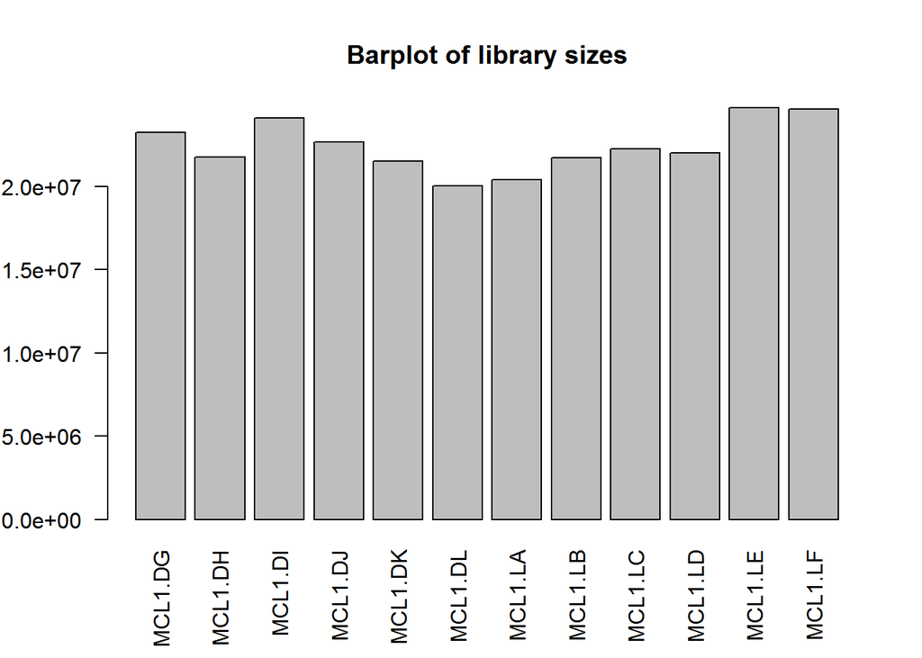

```r
# The names argument tells the barplot to use the sample names on the x-axis
          # The las argument rotates the axis names
          barplot(y$samples$lib.size,names=colnames(y),las=2)
          # Add a title to the plot
          title("Barplot of library sizes")
```

Count data is not normally distributed, so if we want to examine the distributions of the raw counts we need to log the counts. Next we’ll use box plots to check the distribution of the read counts on the log2 scale. We can use the `cpm` function to get log2 counts per million, which are corrected for the different library sizes. The `cpm` function also adds a small offset to avoid taking log of zero.

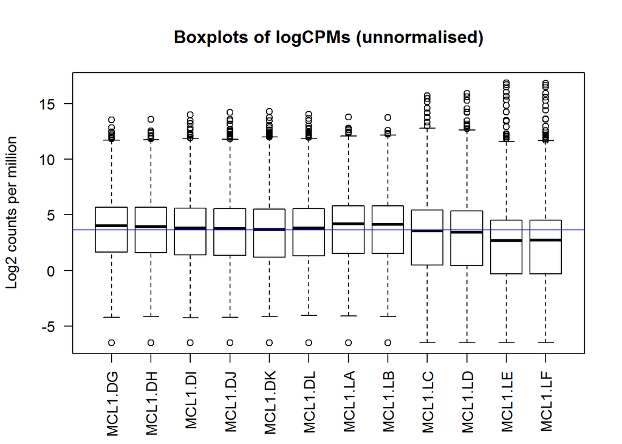

```r
# Get log2 counts per million
          logcounts <- cpm(y,log=TRUE)
          # Check distributions of samples using boxplots
          boxplot(logcounts, xlab="", ylab="Log2 counts per million",las=2)
          # Let's add a blue horizontal line that corresponds to the median logCPM
          abline(h=median(logcounts),col="blue")
          title("Boxplots of logCPMs (unnormalised)")
```

From the boxplots we see that overall the density distributions of raw log-intensities are not identical but still not very different. If a sample is really far above or below the blue horizontal line we may need to investigate that sample further.

## Discussion

> Do any samples appear to be different compared to the others?

### Multidimensional scaling plots

By far, one of the most important plots we make when we analyse RNA-Seq data are MDSplots. An MDSplot is a visualisation of a principle components analysis, which determines the greatest sources of variation in the data. A principle components analysis is an example of an unsupervised analysis, where we don’t need to specify the groups. If your experiment is well controlled and has worked well, what we hope to see is that the greatest sources of variation in the data are the treatments/groups we are interested in. It is also an incredibly useful tool for quality control and checking for outliers. We can use the `plotMDS` function to create the MDS plot.

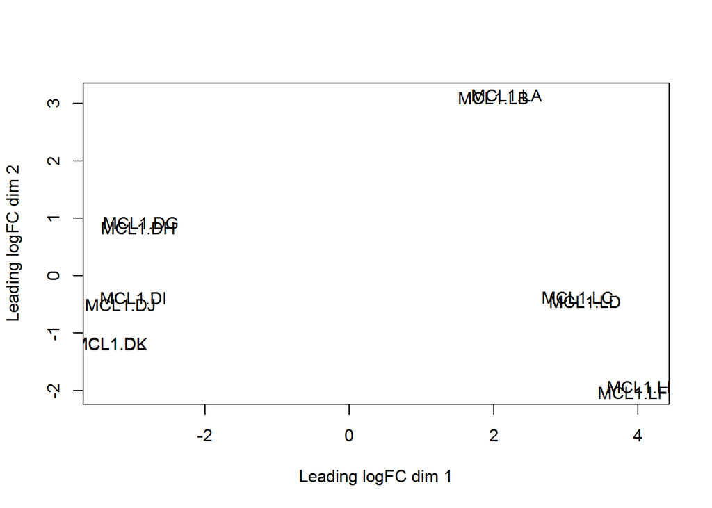

```r
plotMDS(y)
```

It is a bit difficult to see exactly what is going on with the default plot, although we do see samples grouping together in pairs. To make this plot more informative, we can colour the samples according to the grouping information. We can also change the labels, or instead of labels we can have points.

```r
# We specify the option to let us plot two plots side-by-sde
          par(mfrow=c(1,2))
          # Let's set up colour schemes for CellType
          # How many cell types and in what order are they stored?
          levels(sampleinfo$CellType)
```

```
[1] "basal"   "luminal"
```

```r
## Let's choose purple for basal and orange for luminal
          col.cell <- c("purple","orange")[sampleinfo$CellType]
          data.frame(sampleinfo$CellType,col.cell)
```

```
   sampleinfo.CellType col.cell
          1              luminal   orange
          2                basal   purple
          3                basal   purple
          4                basal   purple
          5                basal   purple
          6                basal   purple
          7                basal   purple
          8              luminal   orange
          9              luminal   orange
          10             luminal   orange
          11             luminal   orange
          12             luminal   orange
```

```r
# Redo the MDS with cell type colouring
          plotMDS(y,col=col.cell)
          # Let's add a legend to the plot so we know which colours correspond to which cell type
          legend("topleft",fill=c("purple","orange"),legend=levels(sampleinfo$CellType))
          # Add a title
          title("Cell type")

          # Similarly for status
          levels(sampleinfo$Status)
```

```
[1] "lactate"  "pregnant" "virgin"
```

```r
col.status <- c("blue","red","dark green")[sampleinfo$Status]
          col.status
```

```
 [1] "dark green" "dark green" "red"        "red"        "blue"
           [6] "blue"       "dark green" "dark green" "red"        "red"
          [11] "blue"       "blue"
```

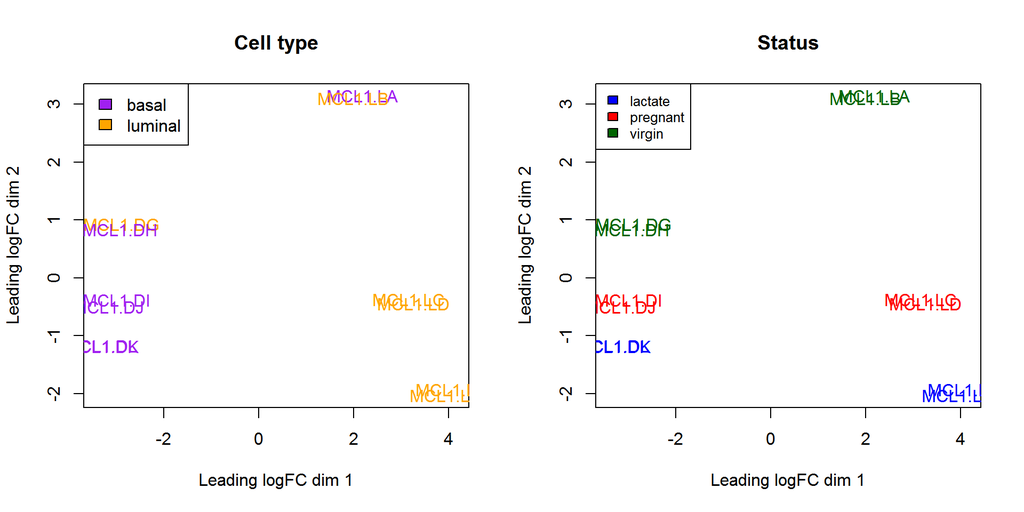

```r
plotMDS(y,col=col.status)
          legend("topleft",fill=c("blue","red","dark green"),legend=levels(sampleinfo$Status),cex=0.8)
          title("Status")
```

## Discussion

> Look at the MDS plot coloured by cell type. Is there something strange going on with the samples? Identify the two samples that don’t appear to be in the right place.

```r
# There is a sample info corrected file in your data directory
          # Old sampleinfo
          sampleinfo
```

```
                            FileName SampleName CellType   Status
          1  MCL1.DG_BC2CTUACXX_ACTTGA_L002_R1    MCL1.DG  luminal   virgin
          2  MCL1.DH_BC2CTUACXX_CAGATC_L002_R1    MCL1.DH    basal   virgin
          3  MCL1.DI_BC2CTUACXX_ACAGTG_L002_R1    MCL1.DI    basal pregnant
          4  MCL1.DJ_BC2CTUACXX_CGATGT_L002_R1    MCL1.DJ    basal pregnant
          5  MCL1.DK_BC2CTUACXX_TTAGGC_L002_R1    MCL1.DK    basal  lactate
          6  MCL1.DL_BC2CTUACXX_ATCACG_L002_R1    MCL1.DL    basal  lactate
          7  MCL1.LA_BC2CTUACXX_GATCAG_L001_R1    MCL1.LA    basal   virgin
          8  MCL1.LB_BC2CTUACXX_TGACCA_L001_R1    MCL1.LB  luminal   virgin
          9  MCL1.LC_BC2CTUACXX_GCCAAT_L001_R1    MCL1.LC  luminal pregnant
          10 MCL1.LD_BC2CTUACXX_GGCTAC_L001_R1    MCL1.LD  luminal pregnant
          11 MCL1.LE_BC2CTUACXX_TAGCTT_L001_R1    MCL1.LE  luminal  lactate
          12 MCL1.LF_BC2CTUACXX_CTTGTA_L001_R1    MCL1.LF  luminal  lactate
```

```r
# I'm going to write over the sampleinfo object with the corrected sample info
          sampleinfo <- read.delim("data/SampleInfo_Corrected.txt")
          sampleinfo
```

```
                            FileName SampleName CellType   Status
          1  MCL1.DG_BC2CTUACXX_ACTTGA_L002_R1    MCL1.DG    basal   virgin
          2  MCL1.DH_BC2CTUACXX_CAGATC_L002_R1    MCL1.DH    basal   virgin
          3  MCL1.DI_BC2CTUACXX_ACAGTG_L002_R1    MCL1.DI    basal pregnant
          4  MCL1.DJ_BC2CTUACXX_CGATGT_L002_R1    MCL1.DJ    basal pregnant
          5  MCL1.DK_BC2CTUACXX_TTAGGC_L002_R1    MCL1.DK    basal  lactate
          6  MCL1.DL_BC2CTUACXX_ATCACG_L002_R1    MCL1.DL    basal  lactate
          7  MCL1.LA_BC2CTUACXX_GATCAG_L001_R1    MCL1.LA  luminal   virgin
          8  MCL1.LB_BC2CTUACXX_TGACCA_L001_R1    MCL1.LB  luminal   virgin
          9  MCL1.LC_BC2CTUACXX_GCCAAT_L001_R1    MCL1.LC  luminal pregnant
          10 MCL1.LD_BC2CTUACXX_GGCTAC_L001_R1    MCL1.LD  luminal pregnant
          11 MCL1.LE_BC2CTUACXX_TAGCTT_L001_R1    MCL1.LE  luminal  lactate
          12 MCL1.LF_BC2CTUACXX_CTTGTA_L001_R1    MCL1.LF  luminal  lactate
```

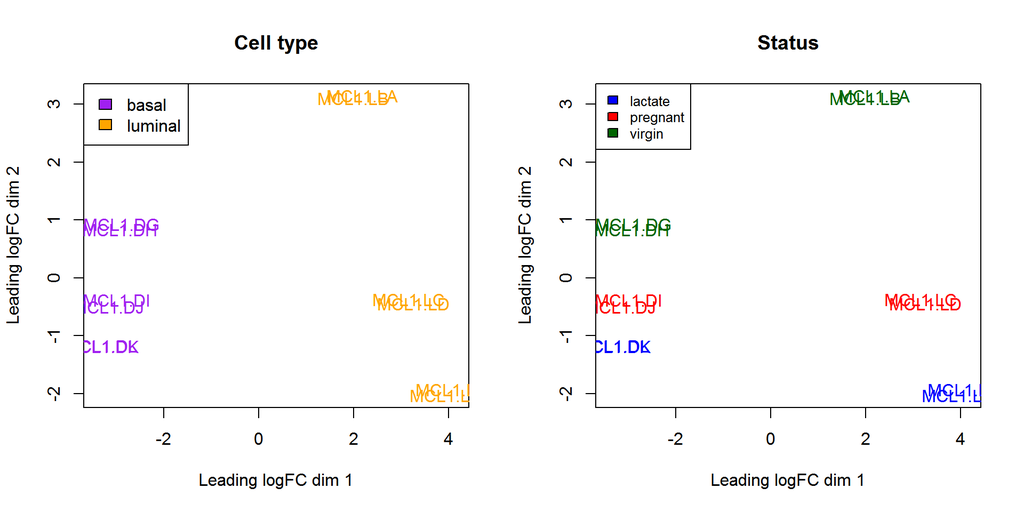

```r
# Redo the MDSplot with corrected information
          par(mfrow=c(1,2))
          col.cell <- c("purple","orange")[sampleinfo$CellType]
          col.status <- c("blue","red","dark green")[sampleinfo$Status]
          plotMDS(y,col=col.cell)
          legend("topleft",fill=c("purple","orange"),legend=levels(sampleinfo$CellType))
          title("Cell type")
          plotMDS(y,col=col.status)
          legend("topleft",fill=c("blue","red","dark green"),legend=levels(sampleinfo$Status),cex=0.8)
          title("Status")
```

## Discussion

> What is the greatest source of variation in the data (i.e. what does dimension 1 represent)? What is the second greatest source of variation in the data?

## Challenge

> 1. Redo the plots choosing your own colours.
> 2. Change the plotting character to a symbol instead of the column names HINT: use `pch` argument. Try `pch=16` and see what happens.
> 3. Change the plotting characters such that basal samples have the value `1` and luminal samples have the value `4`. Colour by status (lactate, pregnant, virgin)

**Solution**

```
[1] "#1B9E77" "#D95F02" "#7570B3"
```

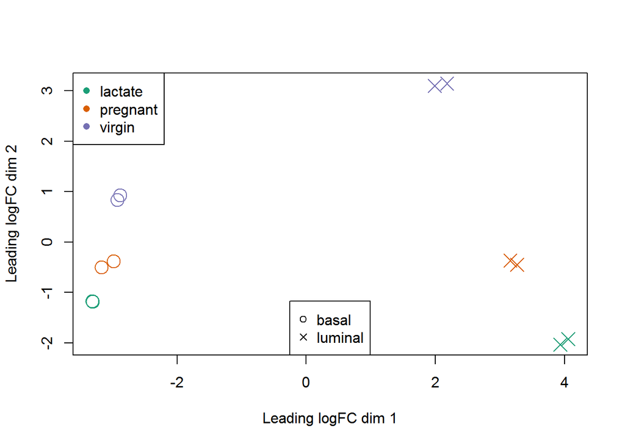

The distance between each pair of samples in the MDS plot is calculated as the leading fold change, defined as the root-mean-square of the largest 500 log2-fold changes between that pair of samples. Replicate samples from the same group cluster together in the plot, while samples from different groups form separate clusters. This indicates that the differences between groups are larger than those within groups, i.e., differential expression is greater than the variance and can be detected. In the MDS plot, the distance between basal samples on the left and luminal cells on the right is about 6 units, corresponding to a leading fold change of about 64-fold (2^6 = 64) between basal and luminal. The expression differences between virgin, pregnant and lactating are greater for luminal cells than for basal.

Notes

- The MDS plot can be simply generated with `plotMDS(y)`. The additional code is purely for aesthetics, to improve the visualization of the groups.
- Clustering in the MDS plot can be used to motivate changes to the design matrix in light of potential batch effects. For example, imagine that the first replicate of each group was prepared at a separate time from the second replicate. If the MDS plot showed separation of samples by time, it might be worthwhile including time in the down stream analysis to account for the time-based effect.

`plotMDS` plots the first two dimensions as a default, however you can plot higher dimensions using the `dim` argument.

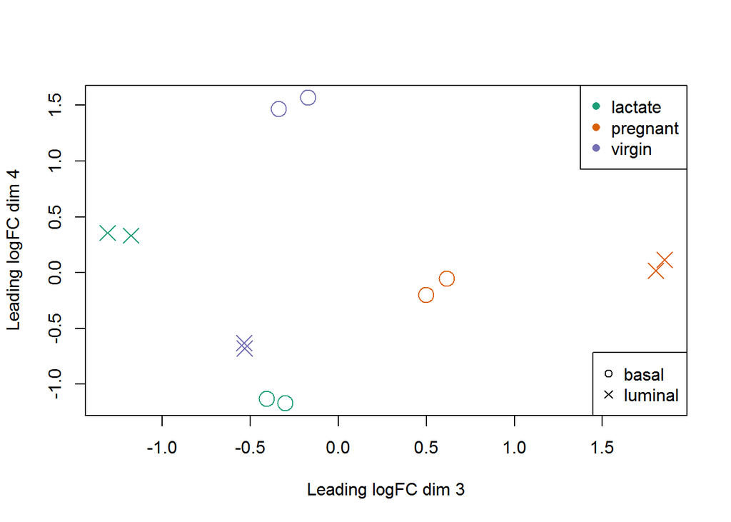

```r
# Dimension 3 appears to separate pregnant samples from the rest. Dim4?
          plotMDS(y,dim=c(3,4),col=col.status,pch=char.celltype,cex=2)
          legend("topright",legend=levels(sampleinfo$Status),col=cols,pch=16)
          legend("bottomright",legend=levels(sampleinfo$CellType),pch=c(1,4))
```

Another alternative is to generate an interactive MDS plot using the *Glimma* package. This allows the user to interactively explore the different dimensions.

```r
labels <- paste(sampleinfo$SampleName, sampleinfo$CellType, sampleinfo$Status)
          group <- paste(sampleinfo$CellType,sampleinfo$Status,sep=".")
          group <- factor(group)
          glMDSPlot(y, labels=labels, groups=group, folder="mds")
```

*Glimma* was created to make interactive versions of some of the popular plots from the *limma* package. At present it can be used to obtain MDS plots and mean-difference (MD) plots, which will be covered later. The output of `glMDSPlot` is an html page (/mds/MDS-Plot.html) that shows the MDS plot on the left, and the amount of variation explained by each dimension in a barplot on the right. The user can hover over points to find out sample information, and switch between successive dimensions in the MDS plot by clicking on the bars in the barplot. The default MDS plots shows dimensions 1 and 2.

### Hierarchical clustering with heatmaps

An alternative to `plotMDS` for examining relationships between samples is using hierarchical clustering. Heatmaps are a nice visualisation to examine hierarchical clustering of your samples. We can do this using the `heatmap.2` function from the *gplots* package. In this example `heatmap.2` calculates a matrix of euclidean distances from the logCPM (`logcounts` object) for the 500 most variable genes. (Note this has more complicated code than plotting principle components using `plotMDS`.)

The *RColorBrewer* package has nicer colour schemes, accessed using the `brewer.pal` function. “RdYlBu” is a common choice, and “Spectral” is also nice.

Note:The `png` function will create a png file to save the plots created straight after, and will close this file when `dev.off()` is called. To see your plots interactively, simply omit those two lines.

Let’s select data for the 500 most variable genes and plot the heatmap

```r
# We estimate the variance for each row in the logcounts matrix
          var_genes <- apply(logcounts, 1, var)
          head(var_genes)
```

```
    497097      20671      27395      18777      21399      58175
          27.4382296  3.3141188  0.1596456  0.1313426  0.3947091  6.2321017
```

```r
# Get the gene names for the top 500 most variable genes
          select_var <- names(sort(var_genes, decreasing=TRUE))[1:500]
          head(select_var)
```

```
[1] "16846"  "72902"  "56747"  "497097" "24117"  "109205"
```

```r
# Subset logcounts matrix
          highly_variable_lcpm <- logcounts[select_var,]
          dim(highly_variable_lcpm)
```

```
[1] 500  12
```

```r
head(highly_variable_lcpm)
```

```
         MCL1.DG  MCL1.DH  MCL1.DI  MCL1.DJ  MCL1.DK  MCL1.DL   MCL1.LA
          16846  0.4290261 1.394877 4.025241 6.068229 5.923462 5.467369 -6.486175
          72902  1.4460253 2.569794 6.084854 5.183325 5.216547 4.629406 -6.486175
          56747  3.3347872 2.975754 5.071799 5.016300 5.599113 6.048402 -6.486175
          497097 4.2384664 3.785840 1.437863 3.388414 4.040841 3.843500 -6.486175
          24117  7.8373931 7.899107 8.634338 8.582153 6.703626 6.776308 -1.710778
          109205 5.5238723 5.717292 6.197664 6.203120 6.526628 6.529395 -6.486175
                    MCL1.LB   MCL1.LC     MCL1.LD   MCL1.LE   MCL1.LF
          16846  -4.1268214 -4.155152 -6.48617500 -6.486175 -6.486175
          72902  -6.4861750 -3.306148 -4.14190372 -6.486175 -6.486175
          56747  -6.4861750 -3.306148 -6.48617500 -4.276248 -4.273190
          497097 -6.4861750 -6.486175 -6.48617500 -6.486175 -6.486175
          24117  -0.7124885 -0.366455  0.01712352 -4.276248 -4.273190
          109205 -1.7975234 -2.388018 -3.29144547 -4.276248 -2.527764
```

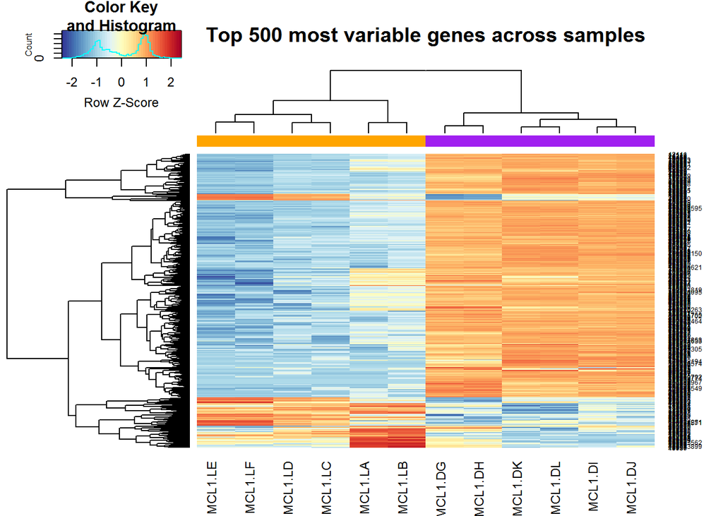

```r
## Get some nicer colours
          mypalette <- brewer.pal(11,"RdYlBu")
          morecols <- colorRampPalette(mypalette)
          # Set up colour vector for celltype variable
          col.cell <- c("purple","orange")[sampleinfo$CellType]

          # Plot the heatmap
          heatmap.2(highly_variable_lcpm,col=rev(morecols(50)),trace="none", main="Top 500 most variable genes across samples",ColSideColors=col.cell,scale="row")
```

```r
# Save the heatmap
          png(file="High_var_genes.heatmap.png")
          heatmap.2(highly_variable_lcpm,col=rev(morecols(50)),trace="none", main="Top 500 most variable genes across samples",ColSideColors=col.cell,scale="row")
          dev.off()
```

## Challenge

> 1. Change the colour scheme to “PiYG” and redo the heatmap. Try `?RColorBrewer` and see what other colour schemes are available.
> 2. Change the sample names to `group` using the `labCol` argument
> 3. Redo the heatmap using the top 500 LEAST variable genes.

**Solution**

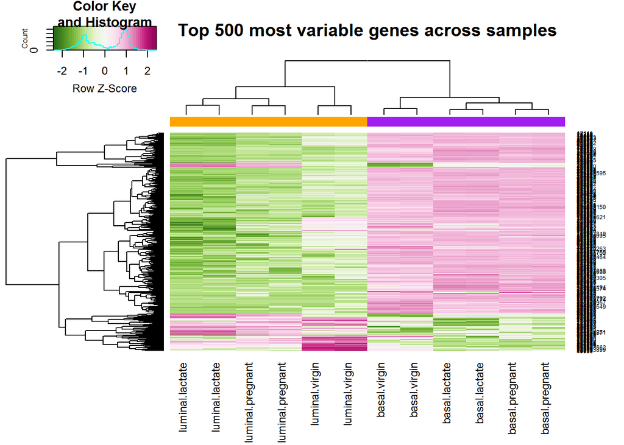

```
[1] "320714" "93684"  "245638" "26433"  "93747"  "236792"
```

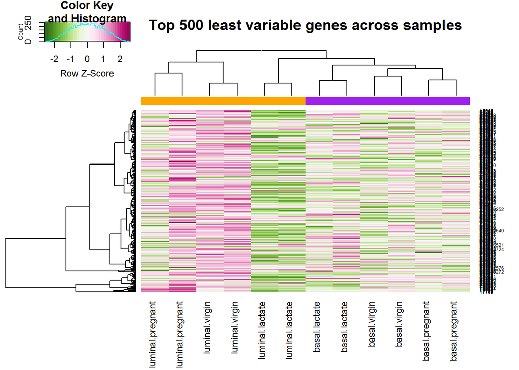

## Normalisation for composition bias

TMM normalization is performed to eliminate composition biases between libraries (Mark D Robinson and Oshlack 2010). This generates a set of normalization factors, where the product of these factors and the library sizes defines the effective library size. The `calcNormFactors` function calculates the normalization factors between libraries. TMM normalisation (and most scaling normalisation methods) scale relative to one sample.

```r
# Apply normalisation to DGEList object
          y <- calcNormFactors(y)
```

This will update the normalisation factors in the `DGEList` object (their default values are 1). Take a look at the normalisation factors for these samples.

```r
y$samples
```

```
        group lib.size norm.factors
          MCL1.DG     1 23218026    1.2368993
          MCL1.DH     1 21768136    1.2139485
          MCL1.DI     1 24091588    1.1255640
          MCL1.DJ     1 22656713    1.0698261
          MCL1.DK     1 21522033    1.0359212
          MCL1.DL     1 20008326    1.0872153
          MCL1.LA     1 20384562    1.3684449
          MCL1.LB     1 21698793    1.3653200
          MCL1.LC     1 22235847    1.0047431
          MCL1.LD     1 21982745    0.9232822
          MCL1.LE     1 24719697    0.5291015
          MCL1.LF     1 24652963    0.5354877
```

The normalization factors multiply to unity across all libraries. A normalization factor below one indicates that the library size will be scaled down, as there is more suppression (i.e., composition bias) in that library relative to the other libraries. This is also equivalent to scaling the counts upwards in that sample. Conversely, a factor above one scales up the library size and is equivalent to downscaling the counts.

The last two samples have much smaller normalisation factors, and MCL1.LA and MCL1.LB have the largest. If we plot mean difference plots using the `plotMD` function for these samples, we should be able to see the composition bias problem. We will use the `logcounts`, which have been normalised for library size, but not for composition bias.

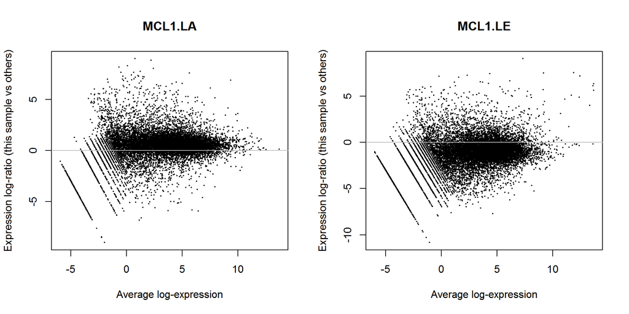

```r
par(mfrow=c(1,2))
          plotMD(logcounts,column = 7)
          abline(h=0,col="grey")
          plotMD(logcounts,column = 11)
          abline(h=0,col="grey")
```

The mean-difference plots show average expression (mean: x-axis) against log-fold-changes (difference: y-axis). Because our `DGEList` object contains the normalisation factors, if we redo these plots using `y`, we should see the composition bias problem has been solved.

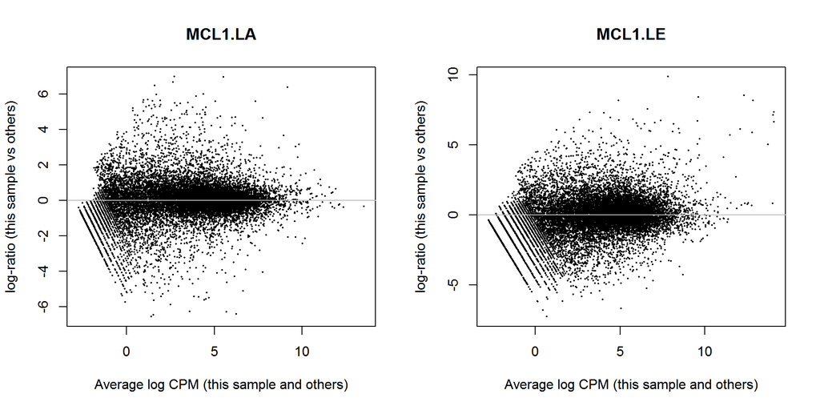

```r
par(mfrow=c(1,2))
          plotMD(y,column = 7)
          abline(h=0,col="grey")
          plotMD(y,column = 11)
          abline(h=0,col="grey")
```

## Challenge

> Plot the biased and unbiased MD plots side by side for the same sample to see the before and after TMM normalisation effect.

**Solution**

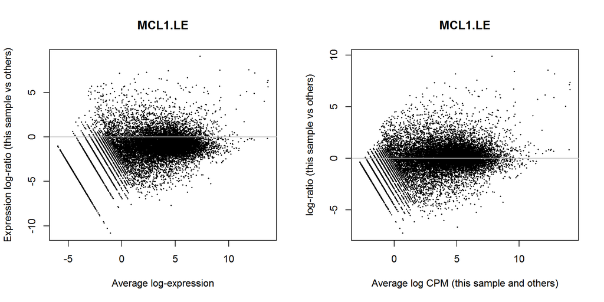

**We need to save a few data objects to use for Day 2 so we don’t have to rerun everything**

```r
# save(group,y,logcounts,sampleinfo,file="day1objects.Rdata")
```

## Differential expression with limma-voom

Now that we are happy that we have normalised the data and that the quality looks good, we can continue to testing for differentially expressed genes. There are a number of packages to analyse RNA-Seq data. The *limma* package (Ritchie et al. 2015) (since version 3.16.0) offers the `voom` function, which transforms the read counts into logCPMs while taking into account the mean-variance relationship in the data (C. W. Law et al. 2014). After vooming, users can apply a linear model to the voom transformed data to test for differentially expressed genes, using standard *limma* commands.

**Load the objects into the workspace that we created yesterday**

```r
# load("day1objects.Rdata")
          # objects()
```

### Create the design matrix

First we need to create a design matrix for the groups (see the excellent [limma user guide](https://bioconductor.org/packages/release/bioc/vignettes/limma/inst/doc/usersguide.pdf) for more information on design matrices). There are many different ways to set up your design matrix, and it is dictated by what comparisons you would like to test. We will follow the set-up from pg 43 of the limma vignette (“Interaction models: 2X2 factorial designs”).

In this analysis let’s assume that we will be testing differences in status in the different cell types separately. For example, we want to know which genes are differentially expressed between pregnant and lactating in basal cells only. We have previously coded the `group` variable, which is a concatenation of cell type and status. Coding the cell type and status in this way allows us to be flexible in specifying which comparisons we are interested in.

```r
# Look at group variable again
          group
```

```
 [1] basal.virgin     basal.virgin     basal.pregnant   basal.pregnant
           [5] basal.lactate    basal.lactate    luminal.virgin   luminal.virgin
           [9] luminal.pregnant luminal.pregnant luminal.lactate  luminal.lactate
          6 Levels: basal.lactate basal.pregnant basal.virgin ... luminal.virgin
```

```r
# Specify a design matrix without an intercept term
          design <- model.matrix(~ 0 + group)
          design
```

```
   groupbasal.lactate groupbasal.pregnant groupbasal.virgin
          1                   0                   0                 1
          2                   0                   0                 1
          3                   0                   1                 0
          4                   0                   1                 0
          5                   1                   0                 0
          6                   1                   0                 0
          7                   0                   0                 0
          8                   0                   0                 0
          9                   0                   0                 0
          10                  0                   0                 0
          11                  0                   0                 0
          12                  0                   0                 0
             groupluminal.lactate groupluminal.pregnant groupluminal.virgin
          1                     0                     0                   0
```

[output cut: 16 more lines]

```r
## Make the column names of the design matrix a bit nicer
          colnames(design) <- levels(group)
          design
```

```
   basal.lactate basal.pregnant basal.virgin luminal.lactate
          1              0              0            1               0
          2              0              0            1               0
          3              0              1            0               0
          4              0              1            0               0
          5              1              0            0               0
          6              1              0            0               0
          7              0              0            0               0
          8              0              0            0               0
          9              0              0            0               0
          10             0              0            0               0
          11             0              0            0               1
          12             0              0            0               1
             luminal.pregnant luminal.virgin
          1                 0              0
```

[output cut: 16 more lines]

Each column of the design matrix tells us which samples correspond to each group. The samples which come from basal cells from a lactating mouse correspond to columns 5 and 6 in the counts matrix, i.e. the samples which have 1s.

### Voom transform the data

Once we have our design matrix ready to go, we can perform our voom transformation. Voom will automatically adjust the library sizes using the `norm.factors` already calculated. The voom transformation uses the experiment design matrix, and produces an `EList` object. We can add `plot=TRUE` to generate a plot of the mean-variance trend. This plot can also tell us if there are any genes that look really variable in our data, and if we’ve filtered the low counts adequately.

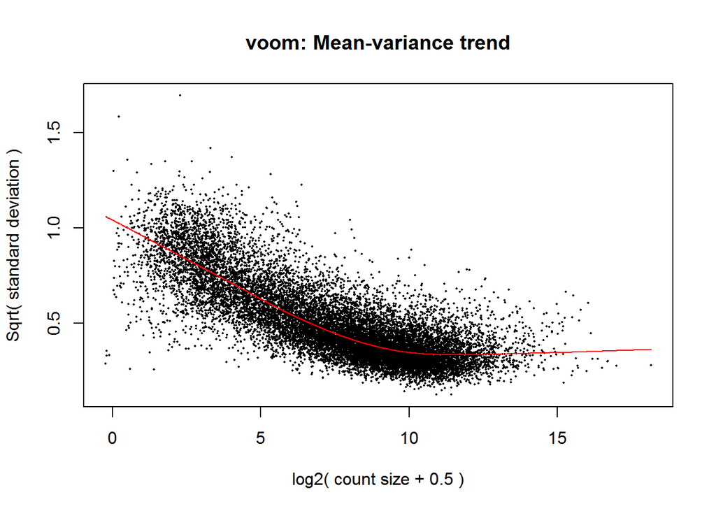

```r
par(mfrow=c(1,1))
          v <- voom(y,design,plot = TRUE)
```

The voom normalised log2 counts can be found in v$E. Take a look at what is in the voom object.

```r
v
```

```
An object of class "EList"
          $targets
                  group lib.size norm.factors
          MCL1.DG     1 28718360     1.236899
          MCL1.DH     1 26425396     1.213949
          MCL1.DI     1 27116624     1.125564
          MCL1.DJ     1 24238743     1.069826
          MCL1.DK     1 22295130     1.035921
          7 more rows ...

          $E
                  MCL1.DG  MCL1.DH  MCL1.DI  MCL1.DJ   MCL1.DK  MCL1.DL    MCL1.LA
          497097 3.932532 3.507368 1.272317 3.292541 3.9909851 3.724252 -5.8019424
          20671  1.890808 2.787899 1.605217 2.121856 0.9642868 1.923156 -0.7575483
          27395  3.429894 3.149591 3.637638 3.631978 3.7037376 3.636318  4.3286281
          18777  4.505933 4.285975 5.128398 5.270351 5.3801014 5.185279  4.8889286
          21399  5.804007 5.822559 5.988345 5.764344 5.7006304 5.615502  5.5801412
                    MCL1.LB    MCL1.LC   MCL1.LD   MCL1.LE    MCL1.LF
          497097 -5.8887821 -5.4816421 -5.343143 -4.709206 -4.7226146
          20671  -0.2163568 -0.2721888 -1.255680 -1.901851 -0.3302972
          27395   3.9707527  4.4535229  4.016606  4.555237  4.6973455
          18777   4.8635986  4.9031416  4.993363  5.379583  5.4610208
          21399   5.4087074  5.5797290  5.512504  5.280898  5.2446116
          15799 more rows ...

          $weights
                   [,1]     [,2]     [,3]     [,4]     [,5]     [,6]       [,7]
          [1,] 42.85032 40.59638 19.78119 18.11020 38.62541 37.98661  0.7907909
          [2,] 21.34610 19.99539 15.74020 14.40027 10.70068 10.49511  4.5401043
          [3,] 35.05544 33.04583 39.72941 36.82081 35.31518 34.70612 50.4586968
          [4,] 56.26175 53.86441 69.16366 66.65108 66.03797 65.46069 64.6692219
          [5,] 76.92857 75.98600 76.79528 75.45282 71.62644 71.16558 73.5980084
                     [,8]       [,9]      [,10]      [,11]      [,12]
          [1,]  0.7907909  0.7907909  0.7907909  0.7907909  0.7907909
          [2,]  4.7399033  3.4277768  3.2224692  2.1314506  2.1428929
          [3,] 52.1833006 45.7806579 43.1302387 38.6112610 38.8559918
          [4,] 66.0984998 60.0161723 57.3174922 54.0693981 54.3410792
          [5,] 74.5613544 70.1642210 68.1238307 50.8570652 51.1210163
          15799 more rows ...

          $design
            basal.lactate basal.pregnant basal.virgin luminal.lactate
          1             0              0            1               0
          2             0              0            1               0
          3             0              1            0               0
          4             0              1            0               0
          5             1              0            0               0
            luminal.pregnant luminal.virgin
          1                0              0
          2                0              0
          3                0              0
          4                0              0
          5                0              0
          7 more rows ...
```

```r
# What is contained in this object?
          names(v)
```

```
[1] "targets" "E"       "weights" "design"
```

## Challenge

> 1. What is in the `targets` slot of `v` and what does it correspond to in `y`?
> 2. What are the dimensions of the `weights` slot in `v`?

We can repeat the box plots for the normalised data to compare to before normalisation. The expression values in `v$E` are already log2 values so we don’t need to log-transform.

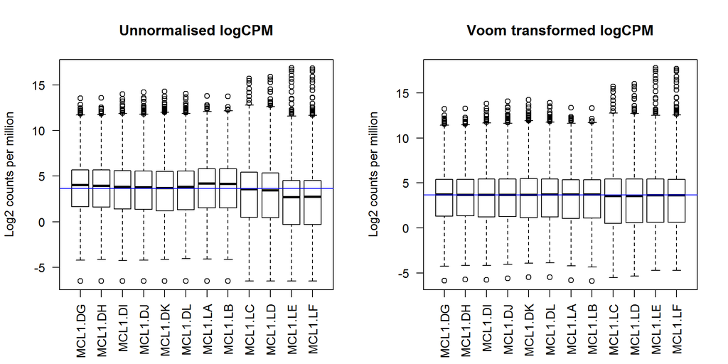

```r
par(mfrow=c(1,2))
          boxplot(logcounts, xlab="", ylab="Log2 counts per million",las=2,main="Unnormalised logCPM")
          ## Let's add a blue horizontal line that corresponds to the median logCPM
          abline(h=median(logcounts),col="blue")
          boxplot(v$E, xlab="", ylab="Log2 counts per million",las=2,main="Voom transformed logCPM")
          ## Let's add a blue horizontal line that corresponds to the median logCPM
          abline(h=median(v$E),col="blue")
```

Compare these box plots to the box plots we generated before performing the normalisation. Can you see any differences?

### Testing for differential expression

Now that we have the voom transformed data we can use *limma* to test for differential expression. First we fit a linear model for each gene using the `lmFit` function in *limma*. `lmFit` needs the voom object and the design matrix that we have already specified, which is stored within the voom object.

```r
# Fit the linear model
          fit <- lmFit(v)
          names(fit)
```

```
 [1] "coefficients"     "stdev.unscaled"   "sigma"
           [4] "df.residual"      "cov.coefficients" "pivot"
           [7] "rank"             "Amean"            "method"
          [10] "design"
```

`lmFit` estimates group means according to the design matrix, as well as gene-wise variances. There are a number of items stored in the `fit` object, most of which are specific to the statistical testing, and we won’t be discussing these in detail today.

Since we are interested in differences between groups, we need to specify which comparisons we want to test. The comparison of interest can be specified using the `makeContrasts` function. Here, we are interested in knowing which genes are differentially expressed between the pregnant and lactating group in the basal cells. This is done by defining the null hypothesis as basal.pregnant - basal.lactate = 0 for each gene. Note that the group names must exactly match the column names of the design matrix.

```r
cont.matrix <- makeContrasts(B.PregVsLac=basal.pregnant - basal.lactate,levels=design)
```

Take a look at the contrast matrix. The contrast matrix tells *limma* which columns of the design matrix we are interested in testing our comparison. Note that here we have specified only one comparison to test, but we can specify as many as we want in one go.

```r
cont.matrix
```

```
                  Contrasts
          Levels             B.PregVsLac
            basal.lactate             -1
            basal.pregnant             1
            basal.virgin               0
            luminal.lactate            0
            luminal.pregnant           0
            luminal.virgin             0
```

Now we can apply the contrasts matrix to the `fit` object to get the statistics and estimated parameters of our comparison that we are interested in. Here we call the `contrasts.fit` function in *limma*.

```r
fit.cont <- contrasts.fit(fit, cont.matrix)
```

The final step is to call the `eBayes` function, which performs empirical Bayes shrinkage on the variances, and estimates moderated t-statistics and the associated p-values.

```r
fit.cont <- eBayes(fit.cont)
```

Check the dimensions of the fit object

```r
dim(fit.cont)
```

```
[1] 15804     1
```

We can use the *limma* `decideTests` function to generate a quick summary of DE genes for the contrasts.

```r
summa.fit <- decideTests(fit.cont)
          summary(summa.fit)
```

```
   B.PregVsLac
          -1        2635
          0        10464
          1         2705
```

## Challenge

> 1. Add another contrast to the contrasts matrix: `L.PregVsLac = luminal.pregnant - luminal.lactate` and re-run the code above. You should have two comparisons in `fit.cont` now.
> 2. Check out the `vennDiagram` function (HINT: type `?vennDiagram`). Can you show the overlap of differentially expressed genes between the two comparisons? How many genes are commonly differentially expressed?

**Solution**

```
   B.PregVsLac L.PregVsLac
          -1        2635        3686
          0        10464        8451
          1         2705        3667
```

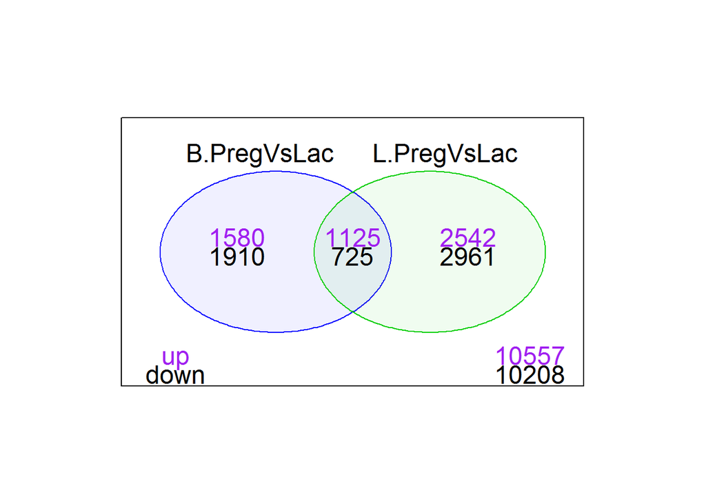

The *limma* `topTable` function summarises the output in a table format. Significant DE genes for a particular comparison can be identified by selecting genes with a p-value smaller than a chosen cut-off value and/or a fold change greater than a chosen value in this table. By default the table will be sorted by the B statistic, which is the log-odds of differential expression. Usually the B statistic and p-value ranking will be the same, but this is not always the case. We will explicitly rank by p-value, which we can specify with the `sort.by` argument.

The `topTable` command will always output the top 10 genes by default, even if they are not statistically significant. We can specify the coefficient we are interested in by the name we used in the contrast matrix (“B.PregVsLac”), or by the column number.

```r
topTable(fit.cont,coef="B.PregVsLac",sort.by="p")
```

```
           logFC  AveExpr         t      P.Value    adj.P.Val        B
          24117   1.819943 2.975545  20.10780 1.063770e-10 1.016240e-06 14.96977
          381290 -2.143885 3.944066 -19.07495 1.982934e-10 1.016240e-06 14.39556
          78896   2.807548 3.036519  18.54773 2.758828e-10 1.016240e-06 14.07416
          226101 -2.329744 6.223525 -18.26861 3.297667e-10 1.016240e-06 13.85802
          16012  -2.896115 1.978449 -18.21525 3.413066e-10 1.016240e-06 13.46984
          231830  2.253400 4.760597  18.02627 3.858161e-10 1.016240e-06 13.67600
          16669  -2.312721 8.741892 -17.07937 7.264548e-10 1.640127e-06 13.17357
          55987  -1.515469 2.834512 -16.64333 9.829870e-10 1.718703e-06 12.88782
          231991 -2.598105 4.275930 -16.53634 1.059885e-09 1.718703e-06 12.66020
          14620   3.600094 3.525281  16.46627 1.113755e-09 1.718703e-06 12.54071
```

```r
## This will give the same output
          topTable(fit.cont,coef=1,sort.by="p")
```

```
           logFC  AveExpr         t      P.Value    adj.P.Val        B
          24117   1.819943 2.975545  20.10780 1.063770e-10 1.016240e-06 14.96977
          381290 -2.143885 3.944066 -19.07495 1.982934e-10 1.016240e-06 14.39556
          78896   2.807548 3.036519  18.54773 2.758828e-10 1.016240e-06 14.07416
          226101 -2.329744 6.223525 -18.26861 3.297667e-10 1.016240e-06 13.85802
          16012  -2.896115 1.978449 -18.21525 3.413066e-10 1.016240e-06 13.46984
          231830  2.253400 4.760597  18.02627 3.858161e-10 1.016240e-06 13.67600
          16669  -2.312721 8.741892 -17.07937 7.264548e-10 1.640127e-06 13.17357
          55987  -1.515469 2.834512 -16.64333 9.829870e-10 1.718703e-06 12.88782
          231991 -2.598105 4.275930 -16.53634 1.059885e-09 1.718703e-06 12.66020
          14620   3.600094 3.525281  16.46627 1.113755e-09 1.718703e-06 12.54071
```

### Adding annotation and saving the results

We have a list of significantly differentially expressed genes, but the only annotation we can see is the Entrez Gene ID, which is not very informative. We would like to add some annotation information. There are a number of ways to do this. We will demonstrate how to do this using the *org.Mm.eg.db* package.

First we need to decide what information we want. In order to see what we can extract we can run the `columns` function on the annotation database.

```r
columns(org.Mm.eg.db)
```

```
 [1] "ACCNUM"       "ALIAS"        "ENSEMBL"      "ENSEMBLPROT"
           [5] "ENSEMBLTRANS" "ENTREZID"     "ENZYME"       "EVIDENCE"
           [9] "EVIDENCEALL"  "GENENAME"     "GO"           "GOALL"
          [13] "IPI"          "MGI"          "ONTOLOGY"     "ONTOLOGYALL"
          [17] "PATH"         "PFAM"         "PMID"         "PROSITE"
          [21] "REFSEQ"       "SYMBOL"       "UNIGENE"      "UNIPROT"
```

We definitely want gene symbols and perhaps the full gene name. Let’s build up our annotation information in a separate data frame using the `select` function.

```r
ann <- select(org.Mm.eg.db,keys=rownames(fit.cont),columns=c("ENTREZID","SYMBOL","GENENAME"))
# Have a look at the annotation
          head(ann)
```

```
  ENTREZID SYMBOL                                  GENENAME
          1   497097   Xkr4         X-linked Kx blood group related 4
          2    20671  Sox17     SRY (sex determining region Y)-box 17
          3    27395 Mrpl15       mitochondrial ribosomal protein L15
          4    18777 Lypla1                       lysophospholipase 1
          5    21399  Tcea1 transcription elongation factor A (SII) 1
          6    58175  Rgs20       regulator of G-protein signaling 20
```

Let’s double check that the `ENTREZID` column matches exactly to our `fit.cont` rownames.

```r
table(ann$ENTREZID==rownames(fit.cont))
```

```
           TRUE
          15804
```

We can slot in the annotation information into the `genes` slot of `fit.cont`. (Please note that if the `select` function returns a 1:many mapping then you can’t just append the annotation to the fit object. An alternative way to get annotation will be discussed tomorrow during the analysis of the second dataset.)

```r
fit.cont$genes <- ann
```

Now when we run the `topTable` command, the annotation information should be included in the output.

```r
topTable(fit.cont,coef="B.PregVsLac",sort.by="p")
```

```
       ENTREZID        SYMBOL                                     GENENAME
          24117     24117          Wif1                      Wnt inhibitory factor 1
          381290   381290        Atp2b4 ATPase, Ca++ transporting, plasma membrane 4
          78896     78896 1500015O10Rik                   RIKEN cDNA 1500015O10 gene
          226101   226101          Myof                                    myoferlin
          16012     16012        Igfbp6 insulin-like growth factor binding protein 6
          231830   231830       Micall2                                 MICAL-like 2
          16669     16669         Krt19                                   keratin 19
          55987     55987         Cpxm2            carboxypeptidase X 2 (M14 family)
          231991   231991         Creb5    cAMP responsive element binding protein 5
          14620     14620          Gjb3                 gap junction protein, beta 3
                     logFC  AveExpr         t      P.Value    adj.P.Val        B
          24117   1.819943 2.975545  20.10780 1.063770e-10 1.016240e-06 14.96977
          381290 -2.143885 3.944066 -19.07495 1.982934e-10 1.016240e-06 14.39556
          78896   2.807548 3.036519  18.54773 2.758828e-10 1.016240e-06 14.07416
          226101 -2.329744 6.223525 -18.26861 3.297667e-10 1.016240e-06 13.85802
          16012  -2.896115 1.978449 -18.21525 3.413066e-10 1.016240e-06 13.46984
          231830  2.253400 4.760597  18.02627 3.858161e-10 1.016240e-06 13.67600
          16669  -2.312721 8.741892 -17.07937 7.264548e-10 1.640127e-06 13.17357
          55987  -1.515469 2.834512 -16.64333 9.829870e-10 1.718703e-06 12.88782
          231991 -2.598105 4.275930 -16.53634 1.059885e-09 1.718703e-06 12.66020
          14620   3.600094 3.525281  16.46627 1.113755e-09 1.718703e-06 12.54071
```

To get the full table (i.e. the information for all genes, not just the top 10) we can specify `n="Inf"`.

```r
limma.res <- topTable(fit.cont,coef="B.PregVsLac",sort.by="p",n="Inf")
```

We can save the results table using the `write.csv` function, which writes the results out to a csv file, which you can open in excel.

```r
write.csv(limma.res,file="B.PregVsLacResults.csv",row.names=FALSE)
```

**A note about deciding how many genes are significant**: In order to decide which genes are differentially expressed, we usually take a cut-off of 0.05 on the adjusted p-value, NOT the raw p-value. This is because we are testing more than 15000 genes, and the chances of finding differentially expressed genes is very high when you do that many tests. Hence we need to control the false discovery rate, which is the adjusted p-value column in the results table. What this means is that if 100 genes are significant at a 5% false discovery rate, we are willing to accept that 5 will be false positives. Note that the `decideTests` function displays significant genes at 5% FDR.

### Plots after testing for DE

Let’s do a few plots to make sure everything looks good and that we haven’t made a mistake in the analysis. Genome-wide plots that are useful for checking are MAplots (or MDplots) and volcano plots. There are functions in limma for plotting these with `fit.cont` as input.

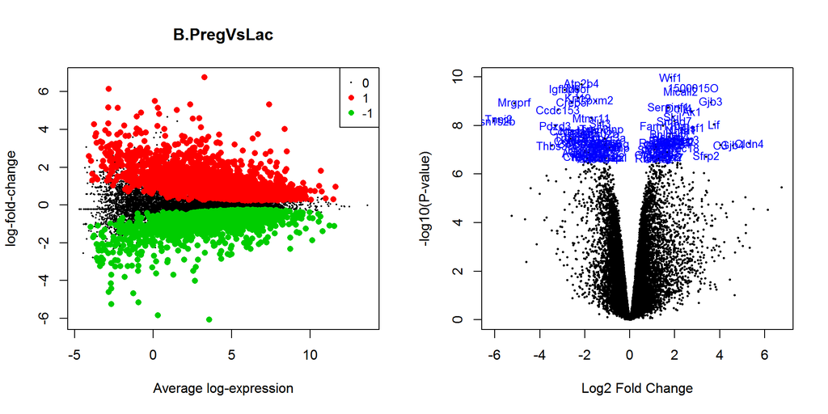

```r
# We want to highlight the significant genes. We can get this from decideTests.
          par(mfrow=c(1,2))
          plotMD(fit.cont,coef=1,status=summa.fit[,"B.PregVsLac"])

          # For the volcano plot we have to specify how many of the top genes to hightlight.
          # We can also specify that we want to plot the gene symbol for the highlighted genes.
          # let's highlight the top 100 most DE genes
          volcanoplot(fit.cont,coef=1,highlight=100,names=fit.cont$genes$SYMBOL)
```

## Challenge

> Look at the MD plot and volcano plot for the second comparison, `L.PregVsLac`. Change the number of highlighted genes to 200 in the volcano plot.

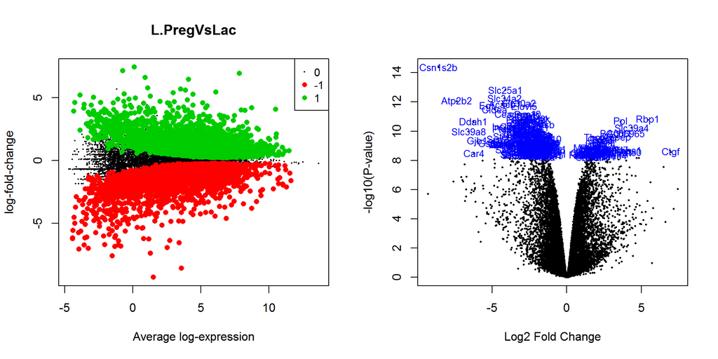

Before following up on the DE genes with further lab work, it is recommended to have a look at the expression levels of the individual samples for the genes of interest. We can quickly look at grouped expression using `stripchart`. We can use the normalised log expression values in the voom object (`v$E`).

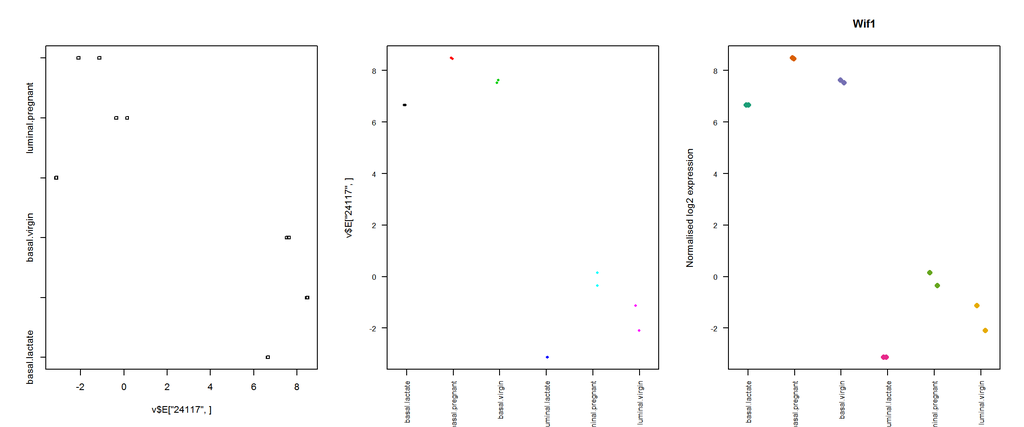

```r
par(mfrow=c(1,3))
          # Let's look at the first gene in the topTable, Wif1, which has a rowname 24117
          stripchart(v$E["24117",]~group)
          # This plot is ugly, let's make it better
          stripchart(v$E["24117",]~group,vertical=TRUE,las=2,cex.axis=0.8,pch=16,col=1:6,method="jitter")
          # Let's use nicer colours
          nice.col <- brewer.pal(6,name="Dark2")
          stripchart(v$E["24117",]~group,vertical=TRUE,las=2,cex.axis=0.8,pch=16,cex=1.3,col=nice.col,method="jitter",ylab="Normalised log2 expression",main="Wif1")
```

Notice anything interesting about the expression of this gene?

## Challenge

> Take the top gene from the L.PregVsLactate comparison and make a stripchart of grouped expression as above. (Don’t forget to change the title of the plot.)

**Solution**

```
       ENTREZID   SYMBOL
          12992     12992  Csn1s2b
          13358     13358  Slc25a1
          20531     20531  Slc34a2
          11941     11941   Atp2b2
          230810   230810  Slc30a2
          100705   100705    Acacb
          68801     68801   Elovl5
          13645     13645      Egf
          12683     12683    Cidea
          26366     26366 Ceacam10
                                                                                        GENENAME
          12992                                                           casein alpha s2-like B
          13358  solute carrier family 25 (mitochondrial carrier, citrate transporter), member 1
          20531                            solute carrier family 34 (sodium phosphate), member 2
```

[output cut: 18 more lines]

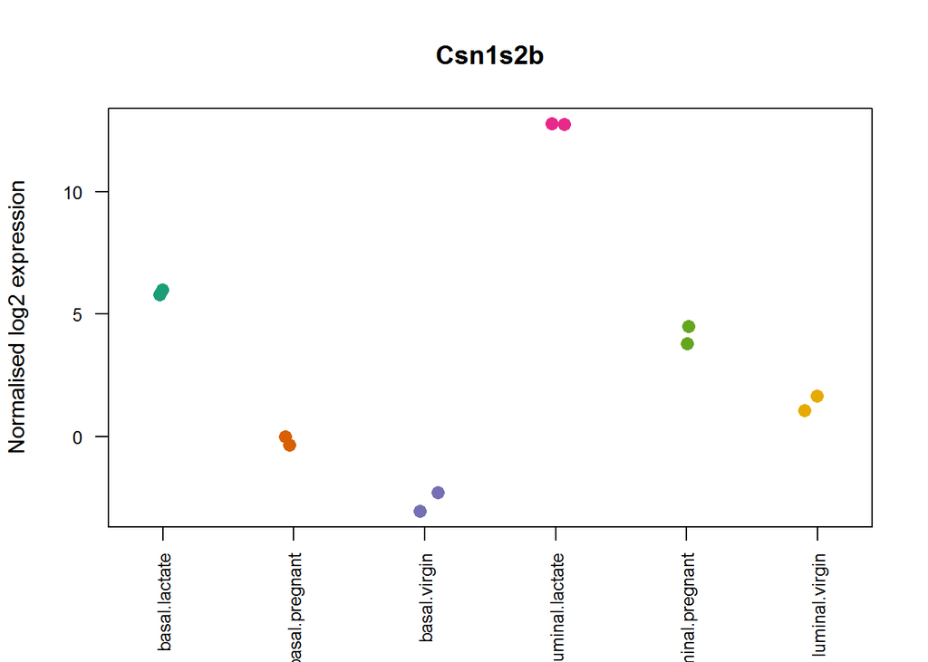

An interactive version of the volcano plot above that includes the raw per sample values in a separate panel is possible via the `glXYPlot` function in the *Glimma* package.

```r
group2 <- group
          levels(group2) <- c("basal.lactate","basal.preg","basal.virgin","lum.lactate", "lum.preg", "lum.virgin")
          glXYPlot(x=fit.cont$coefficients[,1], y=fit.cont$lods[,1],
                   xlab="logFC", ylab="B", main="B.PregVsLac",
                   counts=y$counts, groups=group2, status=summa.fit[,1],
                   anno=fit.cont$genes, side.main="ENTREZID", folder="volcano")
```

This function creates an html page (./volcano/XY-Plot.html) with a volcano plot on the left and a plot showing the log-CPM per sample for a selected gene on the right. A search bar is available to search for genes of interest.

### Testing relative to a threshold (TREAT)

When there is a lot of differential expression, sometimes we may want to cut-off on a fold change threshold as well as a p-value threshold so that we follow up on the most biologically significant genes. However, it is not recommended to simply rank by p-value and then discard genes with small logFC’s, as this has been shown to increase the false discovery rate. In other words, you are not controlling the false discovery rate at 5% anymore. There is a function called `treat` in the *limma* package that performs this style of analysis correctly (D. J. McCarthy and Smyth 2009). `treat` will simply take our `fit.cont` object, as well as a user-specified log fold change cut-off, and recalculate the moderated t-statistics and p-values with the new information about logFC.

```r
# Let's decide that we are only interested in genes that have a absolute logFC of 1.
          # This corresponds to a fold change of 2, or 0.5 (i.e. double or half).
          # We can perform a treat analysis which ranks our genes according to p-value AND logFC.
          # This is easy to do after our analysis, we just give the treat function the fit.cont object and specify our cut-off.
          fit.treat <- treat(fit.cont,lfc=1)
          res.treat <- decideTests(fit.treat)
          summary(res.treat)
```

```
   B.PregVsLac L.PregVsLac
          -1          53         631
          0        15677       14775
          1           74         398
```

```r
topTable(fit.treat,coef=1,sort.by="p")
```

```
       ENTREZID        SYMBOL                                     GENENAME
          211577   211577        Mrgprf                    MAS-related GPR, member F
          78896     78896 1500015O10Rik                   RIKEN cDNA 1500015O10 gene
          16012     16012        Igfbp6 insulin-like growth factor binding protein 6
          21953     21953         Tnni2                 troponin I, skeletal, fast 2
          14620     14620          Gjb3                 gap junction protein, beta 3
          12992     12992       Csn1s2b                       casein alpha s2-like B
          270150   270150       Ccdc153            coiled-coil domain containing 153
          226101   226101          Myof                                    myoferlin
          381290   381290        Atp2b4 ATPase, Ca++ transporting, plasma membrane 4
          231991   231991         Creb5    cAMP responsive element binding protein 5
                     logFC    AveExpr         t      P.Value    adj.P.Val
          211577 -5.146268 -0.9368335 -13.18562 7.329299e-09 6.669358e-05
          78896   2.807548  3.0365195  11.94135 2.234154e-08 6.669358e-05
          16012  -2.896115  1.9784488 -11.92570 2.267536e-08 6.669358e-05
          21953  -5.827889  0.3020716 -11.93183 2.295775e-08 6.669358e-05
          14620   3.600094  3.5252805  11.89242 2.342636e-08 6.669358e-05
          12992  -6.070143  3.5629500 -11.83199 2.532027e-08 6.669358e-05
          270150 -3.211148 -1.3408388 -10.67393 7.828123e-08 1.767367e-04
          226101 -2.329744  6.2235246 -10.42714 1.012983e-07 2.001148e-04
          381290 -2.143885  3.9440659 -10.17758 1.322118e-07 2.050763e-04
          231991 -2.598105  4.2759295 -10.17157 1.330809e-07 2.050763e-04
```

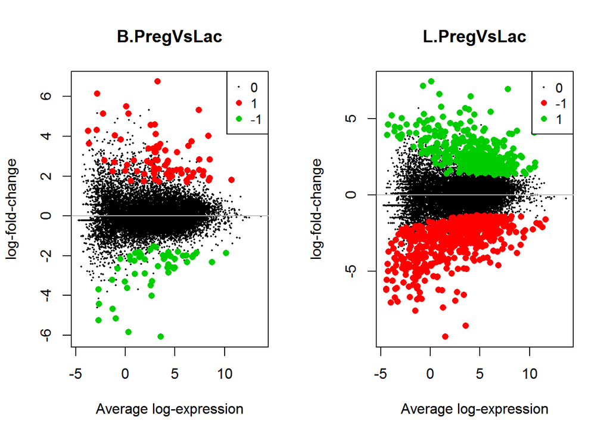

```r
# Notice that much fewer genes are highlighted in the MAplot
          par(mfrow=c(1,2))
          plotMD(fit.treat,coef=1,status=res.treat[,"B.PregVsLac"])
          abline(h=0,col="grey")
          plotMD(fit.treat,coef=2,status=res.treat[,"L.PregVsLac"])
          abline(h=0,col="grey")
```

## Challenge

> Change the cut-off so that we are interested in genes that change at least 50% on the fold change scale.

> HINT: what is the corresponding logFC value of 50% fold change? Assume basal.pregnant is 50% higher than basal.lactate

**Solution**

```
   B.PregVsLac L.PregVsLac
          -1         234        1328
          0        15250       13397
          1          320        1079
```

```
       ENTREZID        SYMBOL                                     GENENAME
          78896     78896 1500015O10Rik                   RIKEN cDNA 1500015O10 gene
          16012     16012        Igfbp6 insulin-like growth factor binding protein 6
          211577   211577        Mrgprf                    MAS-related GPR, member F
          381290   381290        Atp2b4 ATPase, Ca++ transporting, plasma membrane 4
          14620     14620          Gjb3                 gap junction protein, beta 3
          226101   226101          Myof                                    myoferlin
          24117     24117          Wif1                      Wnt inhibitory factor 1
          231830   231830       Micall2                                 MICAL-like 2
          21953     21953         Tnni2                 troponin I, skeletal, fast 2
          231991   231991         Creb5    cAMP responsive element binding protein 5
                     logFC    AveExpr         t      P.Value    adj.P.Val
          78896   2.807548  3.0365195  14.68324 2.122741e-09 1.107588e-05
          16012  -2.896115  1.9784488 -14.53610 2.387463e-09 1.107588e-05
          211577 -5.146268 -0.9368335 -14.50548 2.595874e-09 1.107588e-05
          381290 -2.143885  3.9440659 -13.87032 4.068604e-09 1.107588e-05
          14620   3.600094  3.5252805  13.79074 4.435571e-09 1.107588e-05
          226101 -2.329744  6.2235246 -13.68164 4.766155e-09 1.107588e-05
          24117   1.819943  2.9755445  13.64479 4.905791e-09 1.107588e-05
          231830  2.253400  4.7605970  13.34681 6.327022e-09 1.249903e-05
          21953  -5.827889  0.3020716 -12.95757 9.721628e-09 1.399330e-05
          231991 -2.598105  4.2759295 -12.81319 1.010560e-08 1.399330e-05
```

An interactive version of the mean-difference plots is possible via the `glMDPlot` function in the *Glimma* package.

```r
glMDPlot(fit.treat, coef=1, counts=y$counts, groups=group2,
                  status=res.treat, id.column="ENTREZID", main="B.PregVsLac",
                  folder="md")
```

As with the volcano plot example above, this function creates an html page (./md/MD-Plot.html) that allows the user to search for their favourite gene.

## Gene Set Testing

Sometimes there is quite a long list of differentially expressed genes to interpret after a differential expression analysis, and it is usually infeasible to go through the list one gene at a time trying to understand it’s biological function. A common downstream procedure is gene set testing, which aims to understand which pathways/gene networks the differentially expressed genes are implicated in.

There are a number of different ways to go about testing for enrichment of biological pathways, and the test you choose usually depends on the question you’re asking. There are two kinds of tests: self-contained and competitive gene set tests. Self-contained tests, which include the `ROAST` procedure, ask the question “Are the genes in the set/pathway differentially expressed as a whole?” Competitive gene set tests, like `goana` and `camera` ask the question whether the differentially expressed genes tend to be over-represented in the gene set, compared to all the other genes in the experiment. These different questions use different statistical methodology.

### Gene ontology testing with goana

First, we will perform a gene ontology (GO) enrichment analysis using the `goana` function in *limma*. There are approximately 20,000 GO terms, and they are split into three categories: BP (biological process), MF (molecular function) and CC (cellular component). `goana` uses annotation from the appropriate Bioconductor package and can be used for any of the five species specified (Hs, Mm, Rn, Dm or Pt). `goana` has an advantage over other methods, such as DAVID, in that there is the option to take into account the gene length bias inherent in RNA-Seq data.

Suppose we want to identify GO terms that are over-represented in the basal lactating group compared to the basal pregnancy group. This can be achieved by applying the goana function to the differential expression results of that comparison. `goana` takes the `fit.cont` object, the coefficient of interest and the species. The top set of most enriched GO terms can be viewed with the topGO function.

```r
go <- goana(fit.cont, coef="B.PregVsLac",species = "Mm")
          topGO(go, n=10)
```

```
                                              Term Ont    N  Up Down
          GO:0003723                             RNA binding  MF 1454 476  160
          GO:1990904               ribonucleoprotein complex  CC  742 293   63
          GO:0030529 intracellular ribonucleoprotein complex  CC  741 292   63
          GO:0022613    ribonucleoprotein complex biogenesis  BP  361 178   24
          GO:0042254                     ribosome biogenesis  BP  244 139    7
          GO:0022626                      cytosolic ribosome  CC  107  80    1
          GO:0006364                         rRNA processing  BP  171 102    2
          GO:0016072                  rRNA metabolic process  BP  197 111    8
          GO:0003676                    nucleic acid binding  MF 2858 714  435
          GO:0032991                  macromolecular complex  CC 4108 937  635
                             P.Up    P.Down
          GO:0003723 1.082317e-53 1.0000000
          GO:1990904 3.128474e-50 1.0000000
          GO:0030529 7.770671e-50 1.0000000
          GO:0022613 3.381031e-46 1.0000000
          GO:0042254 1.149588e-45 1.0000000
          GO:0022626 1.948117e-39 1.0000000
          GO:0006364 3.565529e-36 1.0000000
          GO:0016072 4.947163e-36 1.0000000
          GO:0003676 2.575720e-33 0.9999123
          GO:0032991 3.237272e-29 0.9999895
```

The row names of the output are the universal identifiers of the GO terms, with one term per row. The Term column gives the names of the GO terms. These terms cover three domains - biological process (BP), cellular component (CC) and molecular function (MF), as shown in the Ont column. The N column represents the total number of genes that are annotated with each GO term. The Up and Down columns represent the number of differentially expressed genes that overlap with the genes in the GO term. The P.Up and P.Down columns contain the p-values for over-representation of the GO term across the set of up- and down-regulated genes, respectively. The output table is sorted by the minimum of P.Up and P.Down by default.

An additional refinement is to supply `goana` with the gene lengths using the `covariate` argument. In the original data matrix that we loaded into R, there is a column called “Length”.

```r
colnames(seqdata)
```

```
 [1] "EntrezGeneID"
           [2] "Length"
           [3] "MCL1.DG_BC2CTUACXX_ACTTGA_L002_R1"
           [4] "MCL1.DH_BC2CTUACXX_CAGATC_L002_R1"
           [5] "MCL1.DI_BC2CTUACXX_ACAGTG_L002_R1"
           [6] "MCL1.DJ_BC2CTUACXX_CGATGT_L002_R1"
           [7] "MCL1.DK_BC2CTUACXX_TTAGGC_L002_R1"
           [8] "MCL1.DL_BC2CTUACXX_ATCACG_L002_R1"
           [9] "MCL1.LA_BC2CTUACXX_GATCAG_L001_R1"
          [10] "MCL1.LB_BC2CTUACXX_TGACCA_L001_R1"
          [11] "MCL1.LC_BC2CTUACXX_GCCAAT_L001_R1"
          [12] "MCL1.LD_BC2CTUACXX_GGCTAC_L001_R1"
          [13] "MCL1.LE_BC2CTUACXX_TAGCTT_L001_R1"
          [14] "MCL1.LF_BC2CTUACXX_CTTGTA_L001_R1"
```

In order to get the gene lengths for every gene in `fit.cont`, we can use the `match` command. Note that the gene length supplied needs to be in the correct order.

```r
m <- match(rownames(fit.cont),seqdata$EntrezGeneID)
          gene_length <- seqdata$Length[m]
          head(gene_length)
```

```
[1] 3634 3130 4203 2433 2847 2241
```

```r
# Rerun goana with gene length information
          go_length <- goana(fit.cont,coef="B.PregVsLac",species="Mm",covariate=gene_length)
          topGO(go_length, n=10)
```

```
                                              Term Ont    N  Up Down
          GO:0003723                             RNA binding  MF 1454 476  160
          GO:1990904               ribonucleoprotein complex  CC  742 293   63
          GO:0030529 intracellular ribonucleoprotein complex  CC  741 292   63
          GO:0042254                     ribosome biogenesis  BP  244 139    7
          GO:0022613    ribonucleoprotein complex biogenesis  BP  361 178   24
          GO:0022626                      cytosolic ribosome  CC  107  80    1
          GO:0006364                         rRNA processing  BP  171 102    2
          GO:0016072                  rRNA metabolic process  BP  197 111    8
          GO:0005840                                ribosome  CC  212 107    5
          GO:0022625       cytosolic large ribosomal subunit  CC   58  49    0
                             P.Up P.Down
          GO:0003723 8.494584e-55      1
          GO:1990904 8.278850e-54      1
          GO:0030529 2.003347e-53      1
          GO:0042254 1.651659e-48      1
          GO:0022613 5.780765e-48      1
          GO:0022626 4.702353e-44      1
          GO:0006364 3.030188e-38      1
          GO:0016072 7.851352e-38      1
          GO:0005840 4.133967e-34      1
          GO:0022625 2.140251e-32      1
```

## Challenge

> Perform GO analysis for the second comparison, “L.PregVsLac”, taking into account gene length information

**Solution**

```
                                    Term Ont    N   Up Down         P.Up
          GO:0005488                       binding  MF 9690 2619 2217 8.445897e-42
          GO:0005634                       nucleus  CC 5548 1628 1207 2.036292e-36
          GO:0003676          nucleic acid binding  MF 2858  938  538 7.282394e-36
          GO:0005515               protein binding  MF 6737 1915 1488 4.110947e-35
          GO:0044444              cytoplasmic part  CC 6646 1580 1902 3.145543e-01
          GO:0010467               gene expression  BP 3948 1213  750 2.870675e-33
          GO:0005739                 mitochondrion  CC 1598  272  568 1.000000e+00
          GO:1901363 heterocyclic compound binding  MF 4367 1314  935 2.189563e-31
          GO:0003723                   RNA binding  MF 1454  526  244 3.019330e-31
          GO:0022626            cytosolic ribosome  CC  107   79    4 3.204763e-31
                           P.Down
          GO:0005488 9.999998e-01
          GO:0005634 9.999999e-01
          GO:0003676 1.000000e+00
          GO:0005515 1.000000e+00
          GO:0044444 2.844972e-33
          GO:0010467 1.000000e+00
          GO:0005739 9.457323e-32
          GO:1901363 9.999999e-01
          GO:0003723 1.000000e+00
          GO:0022626 1.000000e+00
```

Notes

- Users can specify the domain of the enriched GO terms in topGO. For instance, topGO(go,ontology=“BP”) lists the top set of most enriched GO terms that are related to a biological process. This avoids other domains that are not of interest.
- The goana function uses the NCBI RefSeq annotation. Therefore, the Entrez Gene identifier (ID) should be supplied for each gene as the row names of the fit object.
- Users should set species according to the organism being studied.

### CAMERA gene set testing using the Broad’s curated gene sets

Other databases of gene sets that are available come from the Broad Institute’s Molecular Signatures Database ([MSigDB](http://software.broadinstitute.org/gsea/msigdb)). CAMERA is good option for testing a very large number of gene sets such as the MSigDB sets, as it is very fast. CAMERA is known as a competitive gene set test, however it has the advantage that it can take into account inter-gene correlation within each gene set (D. Wu and Smyth 2012). It also works seemlessly with a `voom` object, taking into account the mean-variance relationship in RNA-Seq data.

Here we will be using the C2 gene sets for mouse, available as .rdata files from the WEHI bioinformatics page http://bioinf.wehi.edu.au/software/MSigDB/index.html. The C2 gene sets contain 4725 curated gene sets collected from a variety of places: BioCarta, KEGG, Pathway Interaction Database, Reactome as well as some published studies.It doesn’t include GO terms.

```r
# Load in the mouse c2 gene sets
          # The R object is called Mm.c2
          load("data/mouse_c2_v5.rdata")
          # Have a look at the first few gene sets
          names(Mm.c2)[1:5]
```

```
[1] "KEGG_GLYCOLYSIS_GLUCONEOGENESIS"
          [2] "KEGG_CITRATE_CYCLE_TCA_CYCLE"
          [3] "KEGG_PENTOSE_PHOSPHATE_PATHWAY"
          [4] "KEGG_PENTOSE_AND_GLUCURONATE_INTERCONVERSIONS"
          [5] "KEGG_FRUCTOSE_AND_MANNOSE_METABOLISM"
```

```r
# Number of gene sets in C2
          length(Mm.c2)
```

```
[1] 4725
```

The gene identifiers are Entrez Gene ID, which is the same as the rownames of our voom object. We need to map the Entrez gene ids between the list of gene sets and our voom object. We can do this using the `ids2indices` function.

```r
c2.ind <- ids2indices(Mm.c2, rownames(v))
```

CAMERA takes as input the voom object `v`, the indexed list of gene sets `c2.ind`, the design matrix, the contrast being tested, as well as some other arguments. By default, CAMERA can estimate the correlation for each gene set separately. However, in practise, it works well to set a small inter-gene correlation of about 0.05 using the `inter.gene.cor` argument.

```r
gst.camera <- camera(v,index=c2.ind,design=design,contrast = cont.matrix[,1],inter.gene.cor=0.05)
```

CAMERA outputs a dataframe of the resulting statistics, with each row denoting a different gene set. The output is ordered by p-value so that the most significant should be at the top. Let’s look at the top 5 gene sets:

```r
gst.camera[1:5,]
```

```
                                                                           NGenes
          REACTOME_PEPTIDE_CHAIN_ELONGATION                                              81
          KEGG_RIBOSOME                                                                  83
          REACTOME_3_UTR_MEDIATED_TRANSLATIONAL_REGULATION                              102
          REACTOME_FORMATION_OF_THE_TERNARY_COMPLEX_AND_SUBSEQUENTLY_THE_43S_COMPLEX     48
          REACTOME_SRP_DEPENDENT_COTRANSLATIONAL_PROTEIN_TARGETING_TO_MEMBRANE          108
                                                                                     Direction
          REACTOME_PEPTIDE_CHAIN_ELONGATION                                                 Up
          KEGG_RIBOSOME                                                                     Up
          REACTOME_3_UTR_MEDIATED_TRANSLATIONAL_REGULATION                                  Up
          REACTOME_FORMATION_OF_THE_TERNARY_COMPLEX_AND_SUBSEQUENTLY_THE_43S_COMPLEX        Up
          REACTOME_SRP_DEPENDENT_COTRANSLATIONAL_PROTEIN_TARGETING_TO_MEMBRANE              Up
                                                                                           PValue
          REACTOME_PEPTIDE_CHAIN_ELONGATION                                          3.711614e-10
          KEGG_RIBOSOME                                                              4.242401e-10
          REACTOME_3_UTR_MEDIATED_TRANSLATIONAL_REGULATION                           1.484636e-09
          REACTOME_FORMATION_OF_THE_TERNARY_COMPLEX_AND_SUBSEQUENTLY_THE_43S_COMPLEX 1.477539e-08
          REACTOME_SRP_DEPENDENT_COTRANSLATIONAL_PROTEIN_TARGETING_TO_MEMBRANE       1.716413e-08
                                                                                              FDR
          REACTOME_PEPTIDE_CHAIN_ELONGATION                                          1.001631e-06
          KEGG_RIBOSOME                                                              1.001631e-06
          REACTOME_3_UTR_MEDIATED_TRANSLATIONAL_REGULATION                           2.336816e-06
          REACTOME_FORMATION_OF_THE_TERNARY_COMPLEX_AND_SUBSEQUENTLY_THE_43S_COMPLEX 1.620981e-05
          REACTOME_SRP_DEPENDENT_COTRANSLATIONAL_PROTEIN_TARGETING_TO_MEMBRANE       1.620981e-05
```

The total number of significant gene sets at 5% FDR is

```r
table(gst.camera$FDR < 0.05)
```

```
          FALSE  TRUE
           4593   129
```

You can write out the camera results to a csv file to open in excel.

```r
write.csv(gst.camera,file="gst_BPregVsLac.csv")
```

## Challenge

> 1. Run `camera` on the second contrast in the contrast matrix.
> 2. Run `camera` on a different set of MSigDB gene sets, the hallmark datasets, `mouse_H_v5.rdata`. You will need to load in the hallmark gene sets, and the object will be called `Mm.H` in R.

**Solution**

```
          FALSE  TRUE
             45     5
```

```
                                   NGenes Direction       PValue
          HALLMARK_MYC_TARGETS_V2                60        Up 7.859018e-09
          HALLMARK_MYC_TARGETS_V1               204        Up 3.706364e-07
          HALLMARK_E2F_TARGETS                  201        Up 1.198872e-04
          HALLMARK_G2M_CHECKPOINT               199        Up 6.547050e-04
          HALLMARK_OXIDATIVE_PHOSPHORYLATION    199        Up 2.493738e-03
          HALLMARK_TGF_BETA_SIGNALING            53        Up 1.068929e-02
          HALLMARK_UNFOLDED_PROTEIN_RESPONSE    110        Up 1.669518e-02
          HALLMARK_CHOLESTEROL_HOMEOSTASIS       73      Down 1.956095e-02
          HALLMARK_ALLOGRAFT_REJECTION          159        Up 5.451666e-02
          HALLMARK_MTORC1_SIGNALING             201        Up 1.088344e-01
                                                      FDR
          HALLMARK_MYC_TARGETS_V2            3.929509e-07
          HALLMARK_MYC_TARGETS_V1            9.265909e-06
          HALLMARK_E2F_TARGETS               1.998120e-03
          HALLMARK_G2M_CHECKPOINT            8.183812e-03
          HALLMARK_OXIDATIVE_PHOSPHORYLATION 2.493738e-02
          HALLMARK_TGF_BETA_SIGNALING        8.907745e-02
          HALLMARK_UNFOLDED_PROTEIN_RESPONSE 1.192513e-01
          HALLMARK_CHOLESTEROL_HOMEOSTASIS   1.222560e-01
          HALLMARK_ALLOGRAFT_REJECTION       3.028704e-01
          HALLMARK_MTORC1_SIGNALING          5.441718e-01
```

### ROAST gene set testing

ROAST is an example of a self-contained gene set test (D. Wu et al. 2010). It asks the question, “Do the genes in my set tend to be differentially expressed between my conditions of interest?”. ROAST doesn’t care about what the other genes in the experiment are doing, which is different to `camera` and `goana`. ROAST is a good option for when you’re interested in a specific set, or a few sets. It is not really used to test thousands of sets at one time.

From the Hallmark gene sets, two MYC pathways were most significant.

```r
H.camera[1:10,]
```

```
                                   NGenes Direction       PValue
          HALLMARK_MYC_TARGETS_V2                60        Up 7.859018e-09
          HALLMARK_MYC_TARGETS_V1               204        Up 3.706364e-07
          HALLMARK_E2F_TARGETS                  201        Up 1.198872e-04
          HALLMARK_G2M_CHECKPOINT               199        Up 6.547050e-04
          HALLMARK_OXIDATIVE_PHOSPHORYLATION    199        Up 2.493738e-03
          HALLMARK_TGF_BETA_SIGNALING            53        Up 1.068929e-02
          HALLMARK_UNFOLDED_PROTEIN_RESPONSE    110        Up 1.669518e-02
          HALLMARK_CHOLESTEROL_HOMEOSTASIS       73      Down 1.956095e-02
          HALLMARK_ALLOGRAFT_REJECTION          159        Up 5.451666e-02
          HALLMARK_MTORC1_SIGNALING             201        Up 1.088344e-01
                                                      FDR
          HALLMARK_MYC_TARGETS_V2            3.929509e-07
          HALLMARK_MYC_TARGETS_V1            9.265909e-06
          HALLMARK_E2F_TARGETS               1.998120e-03
          HALLMARK_G2M_CHECKPOINT            8.183812e-03
          HALLMARK_OXIDATIVE_PHOSPHORYLATION 2.493738e-02
          HALLMARK_TGF_BETA_SIGNALING        8.907745e-02
          HALLMARK_UNFOLDED_PROTEIN_RESPONSE 1.192513e-01
          HALLMARK_CHOLESTEROL_HOMEOSTASIS   1.222560e-01
          HALLMARK_ALLOGRAFT_REJECTION       3.028704e-01
          HALLMARK_MTORC1_SIGNALING          5.441718e-01
```

Let’s see if there are any MYC signalling pathways in MsigDB C2 collection. We can do this with the `grep` command on the names of the gene sets.

```r
grep("MYC_",names(c2.ind))
```

```
 [1]  496  544  621 1591 1592 1783 1784 2029 2030 2031 2032 2194 2195 2203
          [15] 2204 2435 2436 2506 2507 2600 2609 2620 2621 2629 2676 2694 2706 2716
          [29] 2727 2744 2786 2824 3311 3401 3817 3943 3944 4204 4205 4206 4207 4433
          [43] 4434 4616
```

```r
# Let's save these so that we can subset c2.ind to test all gene sets with MYC in the name
          myc <- grep("MYC_",names(c2.ind))
          # What are these pathways called?
          names(c2.ind)[myc]
```

```
 [1] "PID_MYC_ACTIV_PATHWAY"
           [2] "PID_MYC_PATHWAY"
           [3] "PID_MYC_REPRESS_PATHWAY"
           [4] "ODONNELL_TARGETS_OF_MYC_AND_TFRC_UP"
           [5] "ODONNELL_TARGETS_OF_MYC_AND_TFRC_DN"
           [6] "CAIRO_PML_TARGETS_BOUND_BY_MYC_UP"
           [7] "CAIRO_PML_TARGETS_BOUND_BY_MYC_DN"
           [8] "SCHLOSSER_MYC_AND_SERUM_RESPONSE_SYNERGY"
           [9] "SCHLOSSER_MYC_TARGETS_REPRESSED_BY_SERUM"
          [10] "SCHLOSSER_MYC_TARGETS_AND_SERUM_RESPONSE_DN"
          [11] "SCHLOSSER_MYC_TARGETS_AND_SERUM_RESPONSE_UP"
          [12] "CEBALLOS_TARGETS_OF_TP53_AND_MYC_UP"
          [13] "CEBALLOS_TARGETS_OF_TP53_AND_MYC_DN"
          [14] "KIM_MYC_AMPLIFICATION_TARGETS_UP"
          [15] "KIM_MYC_AMPLIFICATION_TARGETS_DN"
```

[output cut: 29 more lines]

Let’s use ROAST to see if these MYC related gene sets tend to be differentially expressed. Note that the syntax for `camera` and `roast` is almost identical.

```r
myc.rst <- roast(v,index=c2.ind[myc],design=design,contrast=cont.matrix[,1],nrot=999)
          myc.rst[1:15,]
```

```
                                            NGenes   PropDown    PropUp
          MENSSEN_MYC_TARGETS                             54 0.11111111 0.7592593
          CAIRO_PML_TARGETS_BOUND_BY_MYC_UP               24 0.08333333 0.7500000
          DANG_REGULATED_BY_MYC_UP                        69 0.10144928 0.7101449
          DANG_MYC_TARGETS_UP                            144 0.09722222 0.7013889
          SCHLOSSER_MYC_TARGETS_AND_SERUM_RESPONSE_UP     48 0.12500000 0.6458333
          PID_MYC_ACTIV_PATHWAY                           79 0.12658228 0.6455696
          SCHLOSSER_MYC_TARGETS_REPRESSED_BY_SERUM       156 0.12820513 0.6217949
          LEE_LIVER_CANCER_MYC_UP                         50 0.30000000 0.5400000
          KIM_MYC_AMPLIFICATION_TARGETS_UP               176 0.14772727 0.5284091
          BILD_MYC_ONCOGENIC_SIGNATURE                   187 0.27272727 0.4973262
          BENPORATH_MYC_TARGETS_WITH_EBOX                216 0.21759259 0.4259259
          MORI_EMU_MYC_LYMPHOMA_BY_ONSET_TIME_DN          16 0.37500000 0.3125000
          COLLER_MYC_TARGETS_UP                           24 0.04166667 0.8333333
          SCHLOSSER_MYC_TARGETS_AND_SERUM_RESPONSE_DN     48 0.06250000 0.7916667
          YU_MYC_TARGETS_UP                               43 0.06976744 0.7674419
                                                      Direction PValue         FDR
          MENSSEN_MYC_TARGETS                                Up  0.001 0.001833333
          CAIRO_PML_TARGETS_BOUND_BY_MYC_UP                  Up  0.001 0.001833333
          DANG_REGULATED_BY_MYC_UP                           Up  0.001 0.001833333
          DANG_MYC_TARGETS_UP                                Up  0.001 0.001833333
          SCHLOSSER_MYC_TARGETS_AND_SERUM_RESPONSE_UP        Up  0.001 0.001833333
          PID_MYC_ACTIV_PATHWAY                              Up  0.001 0.001833333
          SCHLOSSER_MYC_TARGETS_REPRESSED_BY_SERUM           Up  0.001 0.001833333
          LEE_LIVER_CANCER_MYC_UP                            Up  0.001 0.001833333
          KIM_MYC_AMPLIFICATION_TARGETS_UP                   Up  0.001 0.001833333
          BILD_MYC_ONCOGENIC_SIGNATURE                       Up  0.001 0.001833333
          BENPORATH_MYC_TARGETS_WITH_EBOX                    Up  0.001 0.001833333
          MORI_EMU_MYC_LYMPHOMA_BY_ONSET_TIME_DN           Down  0.001 0.001833333
          COLLER_MYC_TARGETS_UP                              Up  0.002 0.004125000
          SCHLOSSER_MYC_TARGETS_AND_SERUM_RESPONSE_DN        Up  0.002 0.004125000
          YU_MYC_TARGETS_UP                                  Up  0.002 0.004125000
                                                      PValue.Mixed FDR.Mixed
          MENSSEN_MYC_TARGETS                                0.001     0.001
          CAIRO_PML_TARGETS_BOUND_BY_MYC_UP                  0.001     0.001
          DANG_REGULATED_BY_MYC_UP                           0.001     0.001
          DANG_MYC_TARGETS_UP                                0.001     0.001
          SCHLOSSER_MYC_TARGETS_AND_SERUM_RESPONSE_UP        0.001     0.001
          PID_MYC_ACTIV_PATHWAY                              0.001     0.001
          SCHLOSSER_MYC_TARGETS_REPRESSED_BY_SERUM           0.001     0.001
          LEE_LIVER_CANCER_MYC_UP                            0.001     0.001
          KIM_MYC_AMPLIFICATION_TARGETS_UP                   0.001     0.001
          BILD_MYC_ONCOGENIC_SIGNATURE                       0.001     0.001
          BENPORATH_MYC_TARGETS_WITH_EBOX                    0.001     0.001
          MORI_EMU_MYC_LYMPHOMA_BY_ONSET_TIME_DN             0.001     0.001
          COLLER_MYC_TARGETS_UP                              0.002     0.002
          SCHLOSSER_MYC_TARGETS_AND_SERUM_RESPONSE_DN        0.002     0.002
          YU_MYC_TARGETS_UP                                  0.001     0.001
```

Each row corresponds to a single gene set. The NGenes column gives the number of genes in each set. The PropDown and PropUp columns contain the proportions of genes in the set that are down- and up-regulated, respectively, with absolute fold changes greater than 2. The net direction of change is determined from the significance of changes in each direction, and is shown in the Direction column. The PValue provides evidence for whether the majority of genes in the set are DE in the specified direction, whereas the PValue.Mixed tests for differential expression in any direction. FDRs are computed from the corresponding p-values across all sets.

## Challenge

> 1. Test whether the MYC signalling pathways tend to be differentially expressed between luminal pregnant vs lactating (the second contrast).
> 2. Look for gene sets containing “WNT” in the name and see whether they tend to be differentially expressed in basal pregnant vs lactating.

**Solution**

```
                                       NGenes  PropDown     PropUp
          ELLWOOD_MYC_TARGETS_DN                     40 0.5750000 0.25000000
          DANG_MYC_TARGETS_DN                        30 0.1666667 0.56666667
          MORI_EMU_MYC_LYMPHOMA_BY_ONSET_TIME_DN     16 0.5625000 0.31250000
          PID_MYC_PATHWAY                            25 0.2400000 0.48000000
          LEE_LIVER_CANCER_MYC_E2F1_DN               42 0.4761905 0.23809524
          PID_MYC_REPRESS_PATHWAY                    59 0.2542373 0.45762712
          KIM_MYC_AMPLIFICATION_TARGETS_DN           82 0.3048780 0.45121951
          BENPORATH_MYC_TARGETS_WITH_EBOX           216 0.3194444 0.43518519
          LEE_LIVER_CANCER_MYC_TGFA_DN               44 0.4318182 0.27272727
          CEBALLOS_TARGETS_OF_TP53_AND_MYC_UP        22 0.3636364 0.09090909
          ODONNELL_TARGETS_OF_MYC_AND_TFRC_DN        45 0.6666667 0.11111111
          CEBALLOS_TARGETS_OF_TP53_AND_MYC_DN        33 0.3030303 0.45454545
          BILD_MYC_ONCOGENIC_SIGNATURE              187 0.2994652 0.45989305
          YU_MYC_TARGETS_UP                          43 0.7209302 0.11627907
          ALFANO_MYC_TARGETS                        220 0.3090909 0.42272727
                                                 Direction PValue         FDR
          ELLWOOD_MYC_TARGETS_DN                      Down  0.001 0.002444444
          DANG_MYC_TARGETS_DN                           Up  0.001 0.002444444
          MORI_EMU_MYC_LYMPHOMA_BY_ONSET_TIME_DN      Down  0.001 0.002444444
          PID_MYC_PATHWAY                               Up  0.001 0.002444444
          LEE_LIVER_CANCER_MYC_E2F1_DN                Down  0.001 0.002444444
          PID_MYC_REPRESS_PATHWAY                       Up  0.001 0.002444444
          KIM_MYC_AMPLIFICATION_TARGETS_DN              Up  0.001 0.002444444
          BENPORATH_MYC_TARGETS_WITH_EBOX               Up  0.001 0.002444444
          LEE_LIVER_CANCER_MYC_TGFA_DN                Down  0.001 0.002444444
          CEBALLOS_TARGETS_OF_TP53_AND_MYC_UP         Down  0.002 0.006600000
          ODONNELL_TARGETS_OF_MYC_AND_TFRC_DN         Down  0.003 0.009166667
          CEBALLOS_TARGETS_OF_TP53_AND_MYC_DN           Up  0.003 0.009166667
          BILD_MYC_ONCOGENIC_SIGNATURE                  Up  0.004 0.011846154
          YU_MYC_TARGETS_UP                           Down  0.005 0.014142857
          ALFANO_MYC_TARGETS                            Up  0.006 0.016133333
                                                 PValue.Mixed FDR.Mixed
          ELLWOOD_MYC_TARGETS_DN                        0.001     0.001
          DANG_MYC_TARGETS_DN                           0.001     0.001
          MORI_EMU_MYC_LYMPHOMA_BY_ONSET_TIME_DN        0.001     0.001
          PID_MYC_PATHWAY                               0.001     0.001
          LEE_LIVER_CANCER_MYC_E2F1_DN                  0.001     0.001
          PID_MYC_REPRESS_PATHWAY                       0.001     0.001
          KIM_MYC_AMPLIFICATION_TARGETS_DN              0.001     0.001
          BENPORATH_MYC_TARGETS_WITH_EBOX               0.001     0.001
          LEE_LIVER_CANCER_MYC_TGFA_DN                  0.001     0.001
          CEBALLOS_TARGETS_OF_TP53_AND_MYC_UP           0.001     0.001
          ODONNELL_TARGETS_OF_MYC_AND_TFRC_DN           0.001     0.001
          CEBALLOS_TARGETS_OF_TP53_AND_MYC_DN           0.001     0.001
          BILD_MYC_ONCOGENIC_SIGNATURE                  0.001     0.001
          YU_MYC_TARGETS_UP                             0.002     0.002
          ALFANO_MYC_TARGETS                            0.001     0.001
```

```
                                    NGenes  PropDown     PropUp Direction
          LABBE_WNT3A_TARGETS_UP                 104 0.2307692 0.49038462        Up
          PID_WNT_NONCANONICAL_PATHWAY            31 0.4516129 0.09677419      Down
          WILLERT_WNT_SIGNALING                   22 0.2272727 0.54545455        Up
          SANSOM_WNT_PATHWAY_REQUIRE_MYC          53 0.1886792 0.45283019        Up
          PID_WNT_CANONICAL_PATHWAY               19 0.4736842 0.21052632      Down
          REACTOME_SIGNALING_BY_WNT               62 0.1290323 0.50000000        Up
          BIOCARTA_WNT_PATHWAY                    24 0.2500000 0.33333333        Up
          ST_WNT_BETA_CATENIN_PATHWAY             32 0.3125000 0.34375000        Up
          KEGG_WNT_SIGNALING_PATHWAY             131 0.3740458 0.25190840      Down
          LABBE_TARGETS_OF_TGFB1_AND_WNT3A_UP    100 0.3400000 0.38000000        Up
          PID_WNT_SIGNALING_PATHWAY               23 0.3043478 0.30434783        Up
          LABBE_TARGETS_OF_TGFB1_AND_WNT3A_DN     90 0.2555556 0.40000000        Up
          ST_WNT_CA2_CYCLIC_GMP_PATHWAY           14 0.2857143 0.35714286        Up
          LABBE_WNT3A_TARGETS_DN                  65 0.2615385 0.27692308        Up
          WNT_SIGNALING                           75 0.3600000 0.30666667      Down
                                              PValue       FDR PValue.Mixed
          LABBE_WNT3A_TARGETS_UP               0.001 0.0037500        0.001
          PID_WNT_NONCANONICAL_PATHWAY         0.001 0.0037500        0.001
          WILLERT_WNT_SIGNALING                0.002 0.0075000        0.001
          SANSOM_WNT_PATHWAY_REQUIRE_MYC       0.004 0.0131250        0.001
          PID_WNT_CANONICAL_PATHWAY            0.014 0.0405000        0.001
          REACTOME_SIGNALING_BY_WNT            0.018 0.0437500        0.005
          BIOCARTA_WNT_PATHWAY                 0.044 0.0875000        0.001
          ST_WNT_BETA_CATENIN_PATHWAY          0.049 0.0875000        0.001
          KEGG_WNT_SIGNALING_PATHWAY           0.053 0.0875000        0.001
          LABBE_TARGETS_OF_TGFB1_AND_WNT3A_UP  0.066 0.0982500        0.001
          PID_WNT_SIGNALING_PATHWAY            0.086 0.1165909        0.001
          LABBE_TARGETS_OF_TGFB1_AND_WNT3A_DN  0.170 0.2118750        0.001
          ST_WNT_CA2_CYCLIC_GMP_PATHWAY        0.248 0.2855769        0.001
          LABBE_WNT3A_TARGETS_DN               0.487 0.5212500        0.001
          WNT_SIGNALING                        0.890 0.8900000        0.001
                                              FDR.Mixed
          LABBE_WNT3A_TARGETS_UP                  0.001
          PID_WNT_NONCANONICAL_PATHWAY            0.001
          WILLERT_WNT_SIGNALING                   0.001
          SANSOM_WNT_PATHWAY_REQUIRE_MYC          0.001
          PID_WNT_CANONICAL_PATHWAY               0.001
          REACTOME_SIGNALING_BY_WNT               0.005
          BIOCARTA_WNT_PATHWAY                    0.001
          ST_WNT_BETA_CATENIN_PATHWAY             0.001
          KEGG_WNT_SIGNALING_PATHWAY              0.001
          LABBE_TARGETS_OF_TGFB1_AND_WNT3A_UP     0.001
          PID_WNT_SIGNALING_PATHWAY               0.001
          LABBE_TARGETS_OF_TGFB1_AND_WNT3A_DN     0.001
          ST_WNT_CA2_CYCLIC_GMP_PATHWAY           0.001
          LABBE_WNT3A_TARGETS_DN                  0.001
          WNT_SIGNALING                           0.001
```

Notes

### Visualising gene set tests: Barcode and enrichment plots

A barcode plot can be produced with the `barcodeplot` function to visualize the results for any particular set. To display a barcodeplot, we need to decide what statistics to use, usually we choose either logFC or t-statistics for the comparison of interest. We also need to make sure we give the statistics in the correct order, such that subsetting the statistics vector will give the genes for the gene set we’re interested in. The best way to do this is to work with the fit object directly. The `coefficients` slot contains the logFCs and the `t` slot contains the t-statistics.

Let’s have a look at one of the top MYC related pathway in the ROAST test that you have already done, “MENSSEN_MYC_TARGETS”.

```r
# Have a look at the logFCs and t-statistics in fit.cont
          names(fit.cont)
```

```
 [1] "coefficients"     "stdev.unscaled"   "sigma"
           [4] "df.residual"      "cov.coefficients" "rank"
           [7] "Amean"            "method"           "design"
          [10] "contrasts"        "df.prior"         "s2.prior"
          [13] "var.prior"        "proportion"       "s2.post"
          [16] "t"                "df.total"         "p.value"
          [19] "lods"             "F"                "F.p.value"
          [22] "genes"
```

```r
head(fit.cont$coefficients)
```

```
        Contrasts
                   B.PregVsLac L.PregVsLac
            497097 -1.62084708  -0.6964826
            20671   0.41298109   0.3652171
            27395  -0.03540567  -0.3849389
            18777  -0.08505647  -0.4731888
            21399   0.21912852   0.2839044
            58175   1.49852621   1.4736067
```

```r
head(fit.cont$t)
```

```
        Contrasts
                   B.PregVsLac L.PregVsLac
            497097  -4.0541969  -0.3076765
            20671    1.0030050   0.4055901
            27395   -0.1936036  -2.2395329
            18777   -0.7975228  -4.0746018
            21399    2.1866392   2.5284968
            58175    1.5788218   3.1387631
```

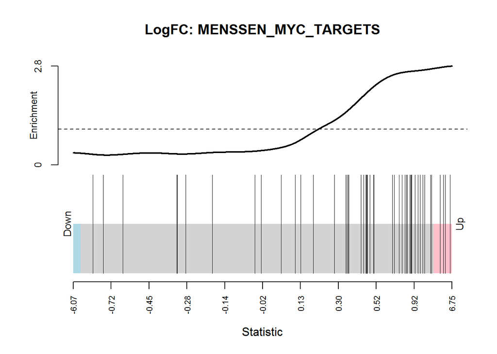

```r
par(mfrow=c(1,1))
          # barcode plot with logFCs
          barcodeplot(fit.cont$coeff[,1], index=c2.ind[["MENSSEN_MYC_TARGETS"]], main="LogFC: MENSSEN_MYC_TARGETS")
```

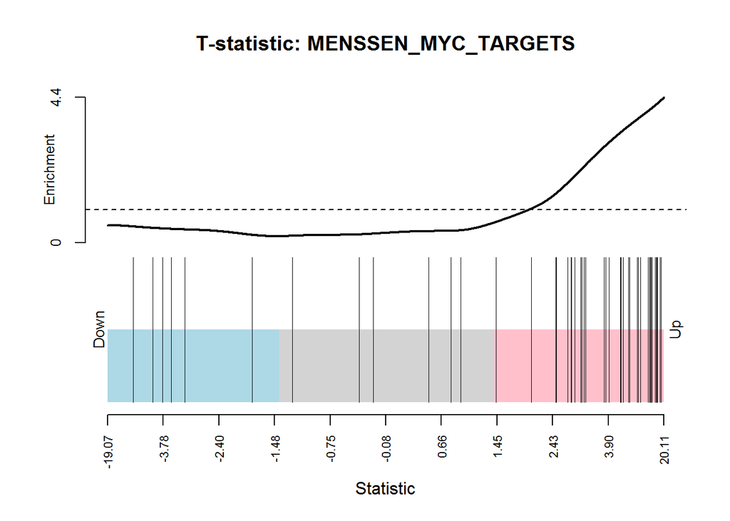

```r
# barcode plot using t-statistics
          barcodeplot(fit.cont$t[,1], index=c2.ind[["MENSSEN_MYC_TARGETS"]], main="T-statistic: MENSSEN_MYC_TARGETS")
```

## Challenge

> 1. Produce a barcodeplot for luminal pregnant vs lactating for this gene set. Does the pattern of enrichment look as strong?
> 2. Choose one of the Wnt signalling pathways and produce a barcode plot for both comparisons.
> 3. You can put two gene sets on one plot, for example a set that is up-regulated and one that is down-regulated, by adding a gene set to the `index2` argument. Produce a barcodeplot with two sets of your choosing.

**Solution**

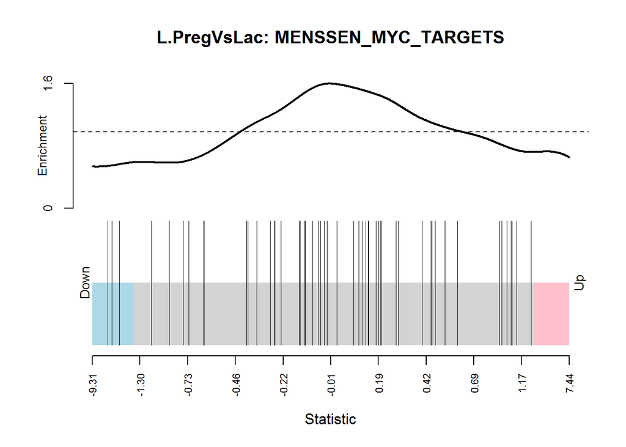

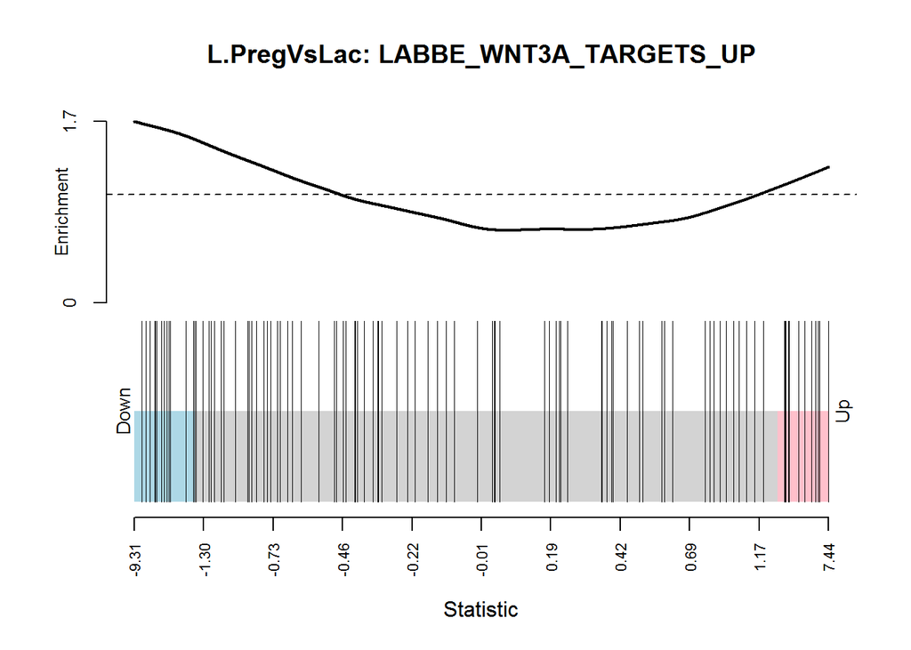

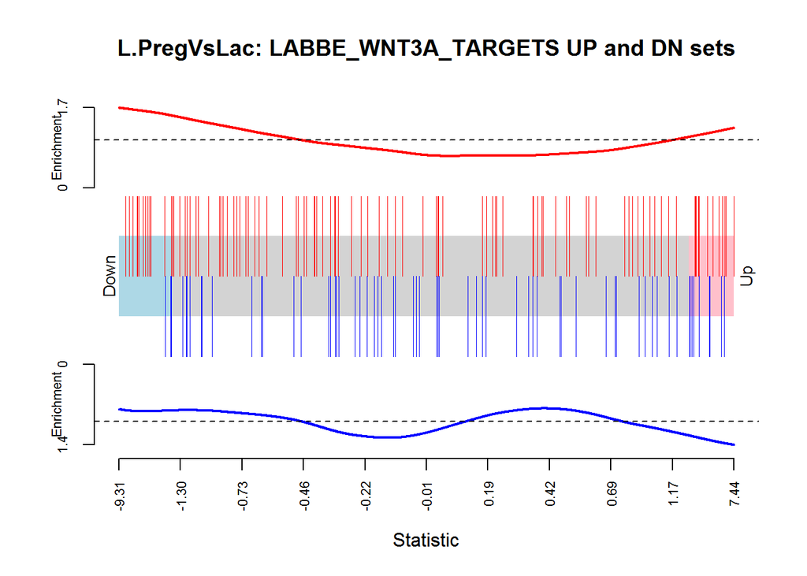

# Record package and version info with sessionInfo()

The session information describes the versions of R and of the packages that were used in the analysis. This is useful for record-keeping purposes, and ensures that an analysis can be reproduced even when the software is updated over time.

[session information not shown]

```
R version 3.4.0 (2017-04-21)
          Platform: x86_64-w64-mingw32/x64 (64-bit)
          Running under: Windows 7 x64 (build 7601) Service Pack 1

          Matrix products: default

          locale:
          [1] LC_COLLATE=English_Australia.1252  LC_CTYPE=English_Australia.1252
          [3] LC_MONETARY=English_Australia.1252 LC_NUMERIC=C
          [5] LC_TIME=English_Australia.1252

          attached base packages:
          [1] parallel  stats4    stats     graphics  grDevices utils     datasets
          [8] methods   base

          other attached packages:
           [1] RColorBrewer_1.1-2   org.Mm.eg.db_3.4.1   AnnotationDbi_1.37.4
           [4] IRanges_2.9.19       S4Vectors_0.13.17    Biobase_2.35.1
           [7] BiocGenerics_0.21.3  gplots_3.0.1         Glimma_1.3.22
          [10] edgeR_3.17.10        limma_3.31.22        knitr_1.16

          loaded via a namespace (and not attached):
           [1] Rcpp_0.12.10       magrittr_1.5       lattice_0.20-35
           [4] BiasedUrn_1.07     stringr_1.2.0      caTools_1.17.1
           [7] tools_3.4.0        grid_3.4.0         KernSmooth_2.23-15
          [10] DBI_0.6-1          htmltools_0.3.5    gtools_3.5.0
          [13] yaml_2.1.14        rprojroot_1.2      digest_0.6.12
          [16] bitops_1.0-6       memoise_1.1.0      RSQLite_1.1-2
          [19] evaluate_0.10      rmarkdown_1.5      gdata_2.17.0
          [22] stringi_1.1.5      GO.db_3.4.1        compiler_3.4.0
          [25] backports_1.1.0    locfit_1.5-9.1     jsonlite_1.4
```

# References

Fu, Nai Yang, Anne C Rios, Bhupinder Pal, Rina Soetanto, Aaron T L Lun, Kevin Liu, Tamara Beck, et al. 2015. “EGF-mediated induction of Mcl-1 at the switch to lactation is essential for alveolar cell survival.” *Nature Cell Biology* 17 (4): 365–75. doi:10.1038/ncb3117.

Law, Charity W, Yunshun Chen, Wei Shi, and Gordon K Smyth. 2014. “Voom: precision weights unlock linear model analysis tools for RNA-seq read counts.” *Genome Biology* 15 (2): R29. doi:10.1186/gb-2014-15-2-r29.

Liao, Yang, Gordon K Smyth, and Wei Shi. 2014. “featureCounts: an efficient general purpose program for assigning sequence reads to genomic features.” *Bioinformatics (Oxford, England)* 30 (7): 923–30. doi:10.1093/bioinformatics/btt656.

Lun, Aaron T L, Yunshun Chen, and Gordon K Smyth. 2016. “It’s DE-licious: A Recipe for Differential Expression Analyses of RNA-seq Experiments Using Quasi-Likelihood Methods in edgeR.” *Methods in Molecular Biology (Clifton, N.J.)* 1418 (January): 391–416. doi:10.1007/978-1-4939-3578-9\_19.

McCarthy, Davis J, and Gordon K Smyth. 2009. “Testing significance relative to a fold-change threshold is a TREAT.” *Bioinformatics (Oxford, England)* 25 (6): 765–71. doi:10.1093/bioinformatics/btp053.

Ritchie, M. E., B. Phipson, D. Wu, Y. Hu, C. W. Law, W. Shi, and G. K. Smyth. 2015. “limma powers differential expression analyses for RNA-sequencing and microarray studies.” *Nucleic Acids Research*, January, gkv007. doi:10.1093/nar/gkv007.

Robinson, M D, D J McCarthy, and G K Smyth. 2010. “edgeR: a Bioconductor package for differential expression analysis of digital gene expression data.” *Bioinformatics* 26 (1). Oxford Univ Press: 139–40.

Robinson, Mark D, and Alicia Oshlack. 2010. “A scaling normalization method for differential expression analysis of RNA-seq data.” *Genome Biology* 11 (3): R25. doi:10.1186/gb-2010-11-3-r25.

Wu, D, and G K Smyth. 2012. “Camera: a competitive gene set test accounting for inter-gene correlation.” *Nucleic Acids Research* 40 (17). Oxford University Press: e133—–e133.

Wu, D, E Lim, F Vaillant, M L Asselin-Labat, J E Visvader, and G K Smyth. 2010. “ROAST: rotation gene set tests for complex microarray experiments.” *Bioinformatics* 26 (17). Oxford Univ Press: 2176–82.